```python
import pandas as pd
import numpy as np
import os
import glob
import math
import matplotlib.pyplot as plt
%matplotlib inline
from scipy.stats import kendalltau
import seaborn as sns
from numpy.random import rand
from numpy.random import seed

pd.set_option('display.max_columns', None)
pd.set_option('display.max_colwidth', -1)
pd.set_option('display.max_rows', None)
pd.options.display.max_seq_items = None #para ver todo df.columns
pd.options.display.float_format = '{:.2f}'.format #para eliminar notación cientifica
```

# Etapa 2: PREPARACION Y CALIDAD DE DATOS

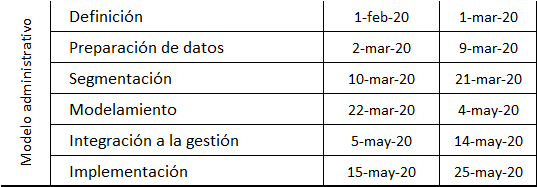

## Revisión documental y control review

### Revisión del diccionario de datos

path=os.chdir(r'\192.168.0.16\Gerencia de Riesgos\Modelos de Riesgo\00. AREA MODELOS\48. BASES DE DATOS MODELOS\Diccionarios')

Diccionario de Cartera de Creditos

Diccionario de variables de razon y numericas

### Revisión del reporte de calidad del ingeniero de datos

path2=os.chdir(r'\192.168.0.16\Gerencia de Riesgos\Modelos de Riesgo\00. AREA MODELOS\48. BASES DE DATOS MODELOS\Python validación bases')

Jupyter Homo Cartera

Jupyter Categoricas

### Análisis de validez

```python
os.chdir(r'C:\Users\nereida.combariza\Documents\06_nuevos_modelos\00. COBRANZA ADMINISTRATIVA\Data_Cobranzas')
```

```python
data_adm3=pd.read_csv('base_ok_completa.txt',encoding = 'ansi', sep=',', dtype={'nro_credito':np.str, 'id':np.str})
```

```python
data_adm3['corte']=data_adm3['Fecha_h']
```

```python
data_adm3.head()
```

|  | nro_credito | id | capital | dias_de_mora | corte | cod_cred_ibs | cod_cred_dialogo | cod_cred | fecha_tex | Fecha | Fecha_h | Fecha_h1 | Fecha_h2 | Fecha_h3 | Fecha_h6 |
| --- | --- | --- | --- | --- | --- | --- | --- | --- | --- | --- | --- | --- | --- | --- | --- |
| 0 | 220001379060 | 90199 | 2465512.00 | 0.00 | 201709.00 | 220001379060.00 | 22011032003952.00 | 220001379060.00 | 30-Sep-17. | sep-17 | 201709.00 | 201710.00 | 201711.00 | 201712.00 | 201801.00 |
| 1 | 220001783790 | 126089 | 6223345.00 | 0.00 | 201709.00 | 220001783790.00 | 22012008004487.00 | 220001783790.00 | 30-Sep-17. | sep-17 | 201709.00 | 201710.00 | 201711.00 | 201712.00 | 201801.00 |
| 2 | 220001152057 | 139442 | 12718876.00 | 0.00 | 201709.00 | 220001152057.00 | 22162009000609.00 | 220001152057.00 | 30-Sep-17. | sep-17 | 201709.00 | 201710.00 | 201711.00 | 201712.00 | 201801.00 |
| 3 | 220001170458 | 145637 | 2414026.00 | 0.00 | 201709.00 | 220001170458.00 | 22164001002149.00 | 220001170458.00 | 30-Sep-17. | sep-17 | 201709.00 | 201710.00 | 201711.00 | 201712.00 | 201801.00 |
| 4 | 220000291154 | 174202 | 4795271.00 | 0.00 | 201709.00 | 220000291154.00 | 22011901001861.00 | 220000291154.00 | 30-Sep-17. | sep-17 | 201709.00 | 201710.00 | 201711.00 | 201712.00 | 201801.00 |

```python
#data_adm3=data_adm3[['id', 'nro_credito', 'capital', 'dias_de_mora', 'corte']].copy()
```

# Construcción de vector de mora

```python
data_adm3['repeticion']=data_adm3.groupby(['nro_credito'])['nro_credito'].transform('count')-1
data_adm3.sort_values(by=['nro_credito','corte'], inplace=True, ascending= [True, False])
```

```python
data_adm3['mora_1m']= data_adm3['dias_de_mora'].copy()
data_adm3['mora_2m']=np.where(data_adm3['nro_credito']==data_adm3['nro_credito'].shift(-1), data_adm3['dias_de_mora'].shift(-1),np.NaN)
data_adm3['mora_3m']=np.where(data_adm3['nro_credito']==data_adm3['nro_credito'].shift(-2), data_adm3['dias_de_mora'].shift(-2),np.NaN)
data_adm3['mora_4m']=np.where(data_adm3['nro_credito']==data_adm3['nro_credito'].shift(-3), data_adm3['dias_de_mora'].shift(-3),np.NaN)
data_adm3['mora_5m']=np.where(data_adm3['nro_credito']==data_adm3['nro_credito'].shift(-4), data_adm3['dias_de_mora'].shift(-4),np.NaN)
data_adm3['mora_6m']=np.where(data_adm3['nro_credito']==data_adm3['nro_credito'].shift(-5), data_adm3['dias_de_mora'].shift(-5),np.NaN)
data_adm3['mora_7m']=np.where(data_adm3['nro_credito']==data_adm3['nro_credito'].shift(-6), data_adm3['dias_de_mora'].shift(-6),np.NaN)
data_adm3['mora_8m']=np.where(data_adm3['nro_credito']==data_adm3['nro_credito'].shift(-7), data_adm3['dias_de_mora'].shift(-7),np.NaN)
data_adm3['mora_9m']=np.where(data_adm3['nro_credito']==data_adm3['nro_credito'].shift(-8), data_adm3['dias_de_mora'].shift(-8),np.NaN)
data_adm3['mora_10m']=np.where(data_adm3['nro_credito']==data_adm3['nro_credito'].shift(-9), data_adm3['dias_de_mora'].shift(-9),np.NaN)
data_adm3['mora_11m']=np.where(data_adm3['nro_credito']==data_adm3['nro_credito'].shift(-10), data_adm3['dias_de_mora'].shift(-10),np.NaN)
data_adm3['mora_12m']=np.where(data_adm3['nro_credito']==data_adm3['nro_credito'].shift(-11), data_adm3['dias_de_mora'].shift(-11),np.NaN)
```

# Construcción de variables sintéticas

## Mora bimestrales

```python
for i in (np.arange(6)+1):
    data_adm3['MORA_MAX_2M_bimestre'+(i).astype('str')] =data_adm3[['mora_'+(2*i-1).astype('str')+'m', 'mora_'+(2*i).astype('str')+'m']].fillna(0).values.max(1)
```

```python
data_adm3.head()
```

|  | nro_credito | id | capital | dias_de_mora | corte | cod_cred_ibs | cod_cred_dialogo | cod_cred | fecha_tex | Fecha | Fecha_h | Fecha_h1 | Fecha_h2 | Fecha_h3 | Fecha_h6 | repeticion | mora_1m | mora_2m | mora_3m | mora_4m | mora_5m | mora_6m | mora_7m | mora_8m | mora_9m | mora_10m | mora_11m | mora_12m | MORA_MAX_2M_bimestre1 | … |
| --- | --- | --- | --- | --- | --- | --- | --- | --- | --- | --- | --- | --- | --- | --- | --- | --- | --- | --- | --- | --- | --- | --- | --- | --- | --- | --- | --- | --- | --- | --- |
| 2545638 | 109506582 | 27221244 | 0.00 | 0.00 | 201911.00 | nan | nan | 109506582.00 | 30-Nov-19. | nov-19 | 201911.00 | 201912.00 | 202001.00 | 202002.00 | 202005.00 | 0.00 | 0.00 | nan | nan | nan | nan | nan | nan | nan | nan | nan | nan | nan | 0.00 | … |
| 2733830 | 131688 | 52615074 | 4990416.71 | 0.00 | 202001.00 | nan | nan | 131688.00 | 31-Ene-20. | ene-20 | 202001.00 | 202002.00 | 202003.00 | 202004.00 | 202007.00 | 8.00 | 0.00 | 0.00 | 0.00 | 0.00 | 0.00 | 0.00 | 0.00 | 0.00 | 0.00 | nan | nan | nan | 0.00 | … |
| 2651825 | 131688 | 52615074 | 5047922.50 | 0.00 | 201912.00 | nan | nan | 131688.00 | 31-Dic-19. | dic-19 | 201912.00 | 202001.00 | 202002.00 | 202003.00 | 202006.00 | 8.00 | 0.00 | 0.00 | 0.00 | 0.00 | 0.00 | 0.00 | 0.00 | 0.00 | nan | nan | nan | nan | 0.00 | … |
| 2566561 | 131688 | 52615074 | 5103502.28 | 0.00 | 201911.00 | nan | nan | 131688.00 | 30-Nov-19. | nov-19 | 201911.00 | 201912.00 | 202001.00 | 202002.00 | 202005.00 | 8.00 | 0.00 | 0.00 | 0.00 | 0.00 | 0.00 | 0.00 | 0.00 | nan | nan | nan | nan | nan | 0.00 | … |
| 2480653 | 131688 | 52615074 | 5157220.57 | 0.00 | 201910.00 | nan | nan | 131688.00 | 31-Oct-19. | oct-19 | 201910.00 | 201911.00 | 201912.00 | 202001.00 | 202004.00 | 8.00 | 0.00 | 0.00 | 0.00 | 0.00 | 0.00 | 0.00 | nan | nan | nan | nan | nan | nan | 0.00 | … |

```python
#Mediana de las ultimas 6 mora bimestrales en el último año
data_adm3['MEDIANA_BIMESTRE_12MESES']=data_adm3[['MORA_MAX_2M_bimestre1','MORA_MAX_2M_bimestre2', 'MORA_MAX_2M_bimestre3','MORA_MAX_2M_bimestre4', 'MORA_MAX_2M_bimestre5','MORA_MAX_2M_bimestre6']].quantile(0.5, axis=1)
```

```python
#Diferencia mora bimestral máxima y mínima en el último año
data_adm3['DIF_MAX_MIN_BIMESTRE_12MESES']=data_adm3[['MORA_MAX_2M_bimestre1','MORA_MAX_2M_bimestre2', 'MORA_MAX_2M_bimestre3',
       'MORA_MAX_2M_bimestre4', 'MORA_MAX_2M_bimestre5',
       'MORA_MAX_2M_bimestre6']].max(axis=1)-data_adm3[['MORA_MAX_2M_bimestre1','MORA_MAX_2M_bimestre2', 'MORA_MAX_2M_bimestre3',
       'MORA_MAX_2M_bimestre4', 'MORA_MAX_2M_bimestre5',
       'MORA_MAX_2M_bimestre6']].min(axis=1)
```

## Moras trimestrales

```python
for i in (np.arange(4)+1):
        data_adm3['MORA_MAX_3M_trimestre'+(i).astype('str')] =data_adm3[['mora_'+(3*i-2).astype('str')+'m', 'mora_'+(3*i-1).astype('str')+'m', 'mora_'+(3*i).astype('str')+'m']].fillna(0).values.max(1)
```

```python
#Mediana de las ultima 4 mora trimestrales en el último año
data_adm3['MEDIANA_TRIMESTRE_12MESES']=data_adm3[['MORA_MAX_3M_trimestre1','MORA_MAX_3M_trimestre2', 'MORA_MAX_3M_trimestre3',
       'MORA_MAX_3M_trimestre4']].quantile(0.5, axis=1)
```

```python
#Diferencia mora trimestral máxima y mínima en el último año
data_adm3['DIF_MAX_MIN_TRIMESTRE_12MESES']=data_adm3[['MORA_MAX_3M_trimestre1','MORA_MAX_3M_trimestre2', 'MORA_MAX_3M_trimestre3',
       'MORA_MAX_3M_trimestre4']].max(axis=1)-data_adm3[['MORA_MAX_3M_trimestre1','MORA_MAX_3M_trimestre2', 'MORA_MAX_3M_trimestre3',
       'MORA_MAX_3M_trimestre4']].min(axis=1)
```

## Moras cuatrimestrales

```python
for i in (np.arange(3)+1):
        data_adm3['MORA_MAX_4M_cuatrimestre'+(i).astype('str')] =data_adm3[['mora_'+(4*i-3).astype('str')+'m','mora_'+(4*i-2).astype('str')+'m', 'mora_'+(4*i-1).astype('str')+'m', 'mora_'+(4*i).astype('str')+'m']].fillna(0).values.max(1)
```

```python
#Mediana de las ultima 4 mora trimestrales en el último año
data_adm3['MEDIANA_CUATRIMESTRE_12MESES']=data_adm3[['MORA_MAX_4M_cuatrimestre1','MORA_MAX_4M_cuatrimestre2', 'MORA_MAX_4M_cuatrimestre3']].quantile(0.5, axis=1)
```

```python
#Diferencia mora cuatrimestral máxima y mínima en el último año
data_adm3['DIF_MAX_MIN_CUATRIMESTRE_12MESES']=data_adm3[['MORA_MAX_4M_cuatrimestre1','MORA_MAX_4M_cuatrimestre2', 'MORA_MAX_4M_cuatrimestre3']].max( axis=1)-data_adm3[['MORA_MAX_4M_cuatrimestre1','MORA_MAX_4M_cuatrimestre2', 'MORA_MAX_4M_cuatrimestre3']].min( axis=1)
```

## Mora semestrales

```python
for i in (np.arange(2)+1):
        data_adm3['MORA_MAX_6M_semestre'+(i).astype('str')] =data_adm3[['mora_'+(6*i-5).astype('str')+'m','mora_'+(6*i-4).astype('str')+'m','mora_'+(6*i-3).astype('str')+'m','mora_'+(6*i-2).astype('str')+'m', 'mora_'+(6*i-1).astype('str')+'m', 'mora_'+(6*i).astype('str')+'m']].fillna(0).values.max(1)
```

```python
#Mediana de las ultima 4 mora trimestrales en el último año
data_adm3['MEDIANA_SEMESTRE_12MESES']=data_adm3[['MORA_MAX_6M_semestre1','MORA_MAX_6M_semestre2']].quantile(0.5, axis=1)
```

```python
#Diferencia mora semestral máxima y mínima en el último año
data_adm3['DIF_MAX_MIN_SEMESTRE_12MESES']=data_adm3[['MORA_MAX_6M_semestre1','MORA_MAX_6M_semestre2']].max(axis=1)-data_adm3[['MORA_MAX_6M_semestre1','MORA_MAX_6M_semestre2']].min(axis=1)
```

# Prueba de perímetro

```python
data_adm3.columns
```

```
Index(['nro_credito', 'id', 'capital', 'dias_de_mora', 'corte', 'cod_cred_ibs',
       'cod_cred_dialogo', 'cod_cred', 'fecha_tex', 'Fecha', 'Fecha_h',
       'Fecha_h1', 'Fecha_h2', 'Fecha_h3', 'Fecha_h6', 'repeticion', 'mora_1m',
       'mora_2m', 'mora_3m', 'mora_4m', 'mora_5m', 'mora_6m', 'mora_7m',
       'mora_8m', 'mora_9m', 'mora_10m', 'mora_11m', 'mora_12m',
       'MORA_MAX_2M_bimestre1', 'MORA_MAX_2M_bimestre2',
       'MORA_MAX_2M_bimestre3', 'MORA_MAX_2M_bimestre4',
       'MORA_MAX_2M_bimestre5', 'MORA_MAX_2M_bimestre6',
       'MEDIANA_BIMESTRE_12MESES', 'DIF_MAX_MIN_BIMESTRE_12MESES',
       'MORA_MAX_3M_trimestre1', 'MORA_MAX_3M_trimestre2',
       'MORA_MAX_3M_trimestre3', 'MORA_MAX_3M_trimestre4',
       'MEDIANA_TRIMESTRE_12MESES', 'DIF_MAX_MIN_TRIMESTRE_12MESES',
       'MORA_MAX_4M_cuatrimestre1', 'MORA_MAX_4M_cuatrimestre2',
       'MORA_MAX_4M_cuatrimestre3', 'MEDIANA_CUATRIMESTRE_12MESES',
       'DIF_MAX_MIN_CUATRIMESTRE_12MESES', 'MORA_MAX_6M_semestre1',
       'MORA_MAX_6M_semestre2', 'MEDIANA_SEMESTRE_12MESES',
       'DIF_MAX_MIN_SEMESTRE_12MESES'],
      dtype='object')
```

```python
data_adm3.groupby(['Fecha_h'])['capital'].agg(['sum','count'])
```

| Fecha_h | sum | count |
| --- | --- | --- |
| 201709.00 | 753674098015.65 | 100315 |
| 201710.00 | 759907044976.16 | 99970 |
| 201711.00 | 767426368995.10 | 99947 |
| 201712.00 | 767437977037.22 | 99180 |
| 201801.00 | 766002750640.63 | 98650 |
| 201802.00 | 770433614026.84 | 98429 |
| 201803.00 | 777077627995.53 | 97535 |
| 201804.00 | 781297677490.72 | 97381 |
| 201805.00 | 783300039477.67 | 96492 |
| 201806.00 | 780657607998.15 | 95142 |
| 201807.00 | 779740722847.76 | 94539 |
| 201808.00 | 780775591234.77 | 93843 |
| 201809.00 | 780986353645.83 | 92991 |
| 201810.00 | 785375805659.52 | 92697 |
| 201811.00 | 789785756394.11 | 92586 |
| 201812.00 | 789871160100.69 | 91627 |
| 201901.00 | 791056110519.79 | 91370 |
| 201902.00 | 793923024041.29 | 91252 |
| 201903.00 | 798019339271.84 | 91344 |
| 201904.00 | 793895322490.22 | 91111 |
| 201905.00 | 791073389439.13 | 90458 |
| 201906.00 | 787212494019.41 | 89540 |
| 201907.00 | 788724579152.39 | 88971 |
| 201908.00 | 789563553659.54 | 88259 |
| 201909.00 | 789760427255.89 | 86599 |
| 201910.00 | 797005575441.98 | 86216 |
| 201911.00 | 798712709470.06 | 85637 |
| 201912.00 | 793363238860.01 | 84645 |
| 202001.00 | 772324303138.59 | 79001 |

Se realiza validación con reporte Historico Cartera por OF_def.xlsx que lleva el área de Riesgo de Credito, evidenciando que los datos en saldos y cantidad de operaciones, cuadran por fecha.

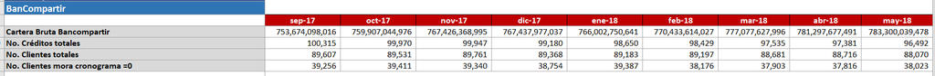

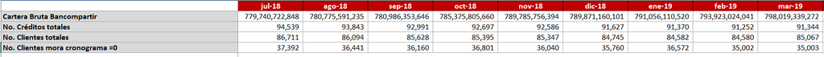

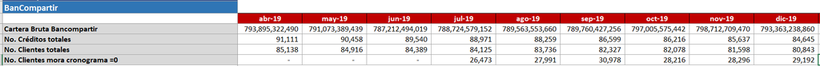

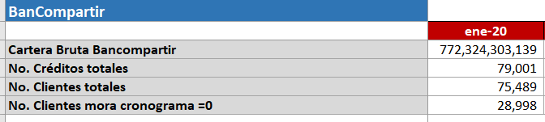

# Selección de la fecha para la población objetivo (po)

```python
data_adm3.Fecha_h.value_counts(dropna=False).sort_index()
```

[output not shown]

```python
data_adm3['Fecha_h'].unique()
```

```
array([201911., 202001., 201912., 201910., 201909., 201908., 201907.,
       201906., 201905., 201904., 201903., 201902., 201901., 201812.,
       201811., 201810., 201809., 201808., 201807., 201806., 201805.,
       201804., 201803., 201802., 201801., 201712., 201711., 201710.,
       201709.])
```

```python
lista_po=[201809., 201810.,
       201811., 201812., 201901., 201902., 201903., 201904., 201905.,
       201906., 201907., 201908., 201909., 201910., 201911., 201912, 202001.]

data_adm3=data_adm3[data_adm3['Fecha_h'].isin(lista_po)].copy()
```

[figure not shown]

```python
data_adm3['Fecha_h'].unique()
```

```
array([201911., 202001., 201912., 201910., 201909., 201908., 201907.,
       201906., 201905., 201904., 201903., 201902., 201901., 201812.,
       201811., 201810., 201809.])
```

### Análisis de completitud

Construyendo la base de cobranza administrativa, mora de 1-30 días

```python
data_adm3=data_adm3.copy()
```

```python
data_adm3.sort_values(by=['Fecha_h','id','dias_de_mora'], inplace=True, ascending= [True, True, False])
```

```python
data_adm3.drop_duplicates(subset=['id','Fecha_h'],inplace=True)
```

```python
data_adm3.shape
```

```
(1419986, 51)
```

```python
data_adm3['mora_adm'] = np.where((data_adm3['dias_de_mora']>1)&(data_adm3['dias_de_mora']<=30),1,0)
```

```python
data_adm3['mora_adm'].agg(['max','min','mean','sum'])
```

```
max    1.00
min    0.00
mean   0.12
sum    172590.00
Name: mora_adm, dtype: float64
```

```python
data_adm3.Fecha_h.value_counts(dropna=False).sort_index()
```

```
201809.00    85628
201810.00    85395
201811.00    85347
201812.00    84745
201901.00    84582
201902.00    84580
201903.00    85067
201904.00    85139
201905.00    84917
201906.00    84390
201907.00    84125
201908.00    83736
201909.00    82327
201910.00    82078
201911.00    81598
201912.00    80843
202001.00    75489
Name: Fecha_h, dtype: int64
```

```python
data_adm3['mora_adm'].value_counts(dropna=False).sort_index()
```

```
0    1247396
1    172590
Name: mora_adm, dtype: int64
```

```python
data_adm3.isna().sum()
```

```
nro_credito                         3
id                                  3
capital                             3
dias_de_mora                        3
corte                               0
cod_cred_ibs                        824856
cod_cred_dialogo                    824856
cod_cred                            3
fecha_tex                           0
Fecha                               0
Fecha_h                             0
Fecha_h1                            0
Fecha_h2                            0
Fecha_h3                            0
Fecha_h6                            0
repeticion                          3
mora_1m                             3
mora_2m                             68165
mora_3m                             136375
mora_4m                             203984
mora_5m                             270118
mora_6m                             334771
mora_7m                             398809
mora_8m                             460673
mora_9m                             520259
mora_10m                            578832
mora_11m                            634978
mora_12m                            689887
MORA_MAX_2M_bimestre1               0
MORA_MAX_2M_bimestre2               0
MORA_MAX_2M_bimestre3               0
MORA_MAX_2M_bimestre4               0
MORA_MAX_2M_bimestre5               0
MORA_MAX_2M_bimestre6               0
MEDIANA_BIMESTRE_12MESES            0
DIF_MAX_MIN_BIMESTRE_12MESES        0
MORA_MAX_3M_trimestre1              0
MORA_MAX_3M_trimestre2              0
MORA_MAX_3M_trimestre3              0
MORA_MAX_3M_trimestre4              0
MEDIANA_TRIMESTRE_12MESES           0
DIF_MAX_MIN_TRIMESTRE_12MESES       0
MORA_MAX_4M_cuatrimestre1           0
MORA_MAX_4M_cuatrimestre2           0
MORA_MAX_4M_cuatrimestre3           0
MEDIANA_CUATRIMESTRE_12MESES        0
DIF_MAX_MIN_CUATRIMESTRE_12MESES    0
MORA_MAX_6M_semestre1               0
MORA_MAX_6M_semestre2               0
MEDIANA_SEMESTRE_12MESES            0
DIF_MAX_MIN_SEMESTRE_12MESES        0
mora_adm                            0
dtype: int64
```

```python
#data_adm4=data_adm3.replace(0,np.NaN).dropna()
data_adm4=data_adm3.copy()
```

```python
data_adm4.shape
```

```
(1419986, 52)
```

```python
data_adm4.columns
```

```
Index(['nro_credito', 'id', 'capital', 'dias_de_mora', 'corte', 'cod_cred_ibs',
       'cod_cred_dialogo', 'cod_cred', 'fecha_tex', 'Fecha', 'Fecha_h',
       'Fecha_h1', 'Fecha_h2', 'Fecha_h3', 'Fecha_h6', 'repeticion', 'mora_1m',
       'mora_2m', 'mora_3m', 'mora_4m', 'mora_5m', 'mora_6m', 'mora_7m',
       'mora_8m', 'mora_9m', 'mora_10m', 'mora_11m', 'mora_12m',
       'MORA_MAX_2M_bimestre1', 'MORA_MAX_2M_bimestre2',
       'MORA_MAX_2M_bimestre3', 'MORA_MAX_2M_bimestre4',
       'MORA_MAX_2M_bimestre5', 'MORA_MAX_2M_bimestre6',
       'MEDIANA_BIMESTRE_12MESES', 'DIF_MAX_MIN_BIMESTRE_12MESES',
       'MORA_MAX_3M_trimestre1', 'MORA_MAX_3M_trimestre2',
       'MORA_MAX_3M_trimestre3', 'MORA_MAX_3M_trimestre4',
       'MEDIANA_TRIMESTRE_12MESES', 'DIF_MAX_MIN_TRIMESTRE_12MESES',
       'MORA_MAX_4M_cuatrimestre1', 'MORA_MAX_4M_cuatrimestre2',
       'MORA_MAX_4M_cuatrimestre3', 'MEDIANA_CUATRIMESTRE_12MESES',
       'DIF_MAX_MIN_CUATRIMESTRE_12MESES', 'MORA_MAX_6M_semestre1',
       'MORA_MAX_6M_semestre2', 'MEDIANA_SEMESTRE_12MESES',
       'DIF_MAX_MIN_SEMESTRE_12MESES', 'mora_adm'],
      dtype='object')
```

Agregando variables de Razon

```python
exo_raz = pd.read_csv('base_exorazon_200806-201912.txt',encoding = 'ansi', sep='\t', dtype={'cedula':np.str})
```

```python
exo_raz.columns
```

```
Index(['tipo_id', 'cedula', 'total_ventas', 'total_costo_ventas',
       'total_gastos_mensuales', 'utilidad', 'total_de_ingresos',
       'egresos_total_egresos', 'capacidad_pago', 'caja_y_bancos',
       'cuentas_por_cobrar', 'total_de_inventario', 'otros_activos_ctes',
       'total_activos_corrientes', 'maquinaria_y_equipo', 'muebles_y_enseres',
       'vehiculos', 'terrenos_y_edificios', 'finca_raiz',
       'otros_activos_fijos', 'total_activos_fijos', 'otros_activos',
       'total_de_activos', 'total_pasivos_ctes', 'total_pasivos_lp',
       'total_pasivos', 'total_patrimonio', 'loan_to_value',
       'endeudamiento_externo', 'porc_uso_tdc', 'corte'],
      dtype='object')
```

exo_raz=exo_raz.drop(['tipo_id', 'utilidad','egresos_total_egresos', 'cuentas_por_cobrar', 'total_de_inventario', 'otros_activos_ctes', 'total_activos_corrientes', 'maquinaria_y_equipo', 'muebles_y_enseres', 'vehiculos', 'terrenos_y_edificios', 'finca_raiz', 'otros_activos_fijos', 'total_activos_fijos', 'otros_activos', 'total_pasivos_ctes', 'total_pasivos_lp', 'total_pasivos', 'total_patrimonio', 'loan_to_value'], axis=1)

```python
data_adm4.columns
```

```
Index(['nro_credito', 'id', 'capital', 'dias_de_mora', 'corte', 'cod_cred_ibs',
       'cod_cred_dialogo', 'cod_cred', 'fecha_tex', 'Fecha', 'Fecha_h',
       'Fecha_h1', 'Fecha_h2', 'Fecha_h3', 'Fecha_h6', 'repeticion', 'mora_1m',
       'mora_2m', 'mora_3m', 'mora_4m', 'mora_5m', 'mora_6m', 'mora_7m',
       'mora_8m', 'mora_9m', 'mora_10m', 'mora_11m', 'mora_12m',
       'MORA_MAX_2M_bimestre1', 'MORA_MAX_2M_bimestre2',
       'MORA_MAX_2M_bimestre3', 'MORA_MAX_2M_bimestre4',
       'MORA_MAX_2M_bimestre5', 'MORA_MAX_2M_bimestre6',
       'MEDIANA_BIMESTRE_12MESES', 'DIF_MAX_MIN_BIMESTRE_12MESES',
       'MORA_MAX_3M_trimestre1', 'MORA_MAX_3M_trimestre2',
       'MORA_MAX_3M_trimestre3', 'MORA_MAX_3M_trimestre4',
       'MEDIANA_TRIMESTRE_12MESES', 'DIF_MAX_MIN_TRIMESTRE_12MESES',
       'MORA_MAX_4M_cuatrimestre1', 'MORA_MAX_4M_cuatrimestre2',
       'MORA_MAX_4M_cuatrimestre3', 'MEDIANA_CUATRIMESTRE_12MESES',
       'DIF_MAX_MIN_CUATRIMESTRE_12MESES', 'MORA_MAX_6M_semestre1',
       'MORA_MAX_6M_semestre2', 'MEDIANA_SEMESTRE_12MESES',
       'DIF_MAX_MIN_SEMESTRE_12MESES', 'mora_adm'],
      dtype='object')
```

```python
exo_raz.columns
```

```
Index(['tipo_id', 'cedula', 'total_ventas', 'total_costo_ventas',
       'total_gastos_mensuales', 'utilidad', 'total_de_ingresos',
       'egresos_total_egresos', 'capacidad_pago', 'caja_y_bancos',
       'cuentas_por_cobrar', 'total_de_inventario', 'otros_activos_ctes',
       'total_activos_corrientes', 'maquinaria_y_equipo', 'muebles_y_enseres',
       'vehiculos', 'terrenos_y_edificios', 'finca_raiz',
       'otros_activos_fijos', 'total_activos_fijos', 'otros_activos',
       'total_de_activos', 'total_pasivos_ctes', 'total_pasivos_lp',
       'total_pasivos', 'total_patrimonio', 'loan_to_value',
       'endeudamiento_externo', 'porc_uso_tdc', 'corte'],
      dtype='object')
```

```python
print(data_adm4.id.dtypes)
print(exo_raz.cedula.dtypes)
print(exo_raz.corte.dtypes)
```

```
object
object
int64
```

```python
print(data_adm4.shape)
data_adm5 = data_adm4.merge(exo_raz, how='left', left_on=['id','Fecha_h'], right_on=['cedula','corte'])
print(data_adm5.shape)
```

```
(1419986, 52)
(1419988, 83)
```

```python
data_adm5=data_adm5[['id', 'nro_credito',  'dias_de_mora',
        'capital', 'corte_x', 'fecha_tex',
       'Fecha', 'Fecha_h', 'Fecha_h1', 'Fecha_h2', 'Fecha_h3', 'Fecha_h6',
       'mora_adm', 'cedula', 'total_ventas', 'total_costo_ventas',
       'total_gastos_mensuales', 'total_de_ingresos', 'capacidad_pago',
       'caja_y_bancos', 'total_de_activos', 'endeudamiento_externo',
       'porc_uso_tdc','MORA_MAX_2M_bimestre1', 'MORA_MAX_2M_bimestre2',
       'MORA_MAX_2M_bimestre3', 'MORA_MAX_2M_bimestre4',
       'MORA_MAX_2M_bimestre5', 'MORA_MAX_2M_bimestre6',
       'MEDIANA_BIMESTRE_12MESES', 'DIF_MAX_MIN_BIMESTRE_12MESES',
       'MORA_MAX_3M_trimestre1', 'MORA_MAX_3M_trimestre2',
       'MORA_MAX_3M_trimestre3', 'MORA_MAX_3M_trimestre4',
       'MEDIANA_TRIMESTRE_12MESES', 'DIF_MAX_MIN_TRIMESTRE_12MESES',
       'MORA_MAX_4M_cuatrimestre1', 'MORA_MAX_4M_cuatrimestre2',
       'MORA_MAX_4M_cuatrimestre3', 'MEDIANA_CUATRIMESTRE_12MESES',
       'DIF_MAX_MIN_CUATRIMESTRE_12MESES', 'MORA_MAX_6M_semestre1',
       'MORA_MAX_6M_semestre2', 'MEDIANA_SEMESTRE_12MESES',
       'DIF_MAX_MIN_SEMESTRE_12MESES', 'mora_adm']]
```

```python
data_adm5.shape
```

```
(1419988, 47)
```

```python
data_adm5.columns=['id', 'nro_credito',  'dias_de_mora',
      'capital', 'corte', 'fecha_tex',
       'Fecha', 'Fecha_h', 'Fecha_h1', 'Fecha_h2', 'Fecha_h3', 'Fecha_h6',
       'mora_adm', 'cedula', 'total_ventas', 'total_costo_ventas',
       'total_gastos_mensuales', 'total_de_ingresos', 'capacidad_pago',
       'caja_y_bancos', 'total_de_activos', 'endeudamiento_externo',
       'porc_uso_tdc','MORA_MAX_2M_bimestre1', 'MORA_MAX_2M_bimestre2',
       'MORA_MAX_2M_bimestre3', 'MORA_MAX_2M_bimestre4',
       'MORA_MAX_2M_bimestre5', 'MORA_MAX_2M_bimestre6',
       'MEDIANA_BIMESTRE_12MESES', 'DIF_MAX_MIN_BIMESTRE_12MESES',
       'MORA_MAX_3M_trimestre1', 'MORA_MAX_3M_trimestre2',
       'MORA_MAX_3M_trimestre3', 'MORA_MAX_3M_trimestre4',
       'MEDIANA_TRIMESTRE_12MESES', 'DIF_MAX_MIN_TRIMESTRE_12MESES',
       'MORA_MAX_4M_cuatrimestre1', 'MORA_MAX_4M_cuatrimestre2',
       'MORA_MAX_4M_cuatrimestre3', 'MEDIANA_CUATRIMESTRE_12MESES',
       'DIF_MAX_MIN_CUATRIMESTRE_12MESES', 'MORA_MAX_6M_semestre1',
       'MORA_MAX_6M_semestre2', 'MEDIANA_SEMESTRE_12MESES',
       'DIF_MAX_MIN_SEMESTRE_12MESES', 'mora_adm']
```

```python
data_adm5.columns
```

```
Index(['id', 'nro_credito', 'dias_de_mora', 'capital', 'corte', 'fecha_tex',
       'Fecha', 'Fecha_h', 'Fecha_h1', 'Fecha_h2', 'Fecha_h3', 'Fecha_h6',
       'mora_adm', 'cedula', 'total_ventas', 'total_costo_ventas',
       'total_gastos_mensuales', 'total_de_ingresos', 'capacidad_pago',
       'caja_y_bancos', 'total_de_activos', 'endeudamiento_externo',
       'porc_uso_tdc', 'MORA_MAX_2M_bimestre1', 'MORA_MAX_2M_bimestre2',
       'MORA_MAX_2M_bimestre3', 'MORA_MAX_2M_bimestre4',
       'MORA_MAX_2M_bimestre5', 'MORA_MAX_2M_bimestre6',
       'MEDIANA_BIMESTRE_12MESES', 'DIF_MAX_MIN_BIMESTRE_12MESES',
       'MORA_MAX_3M_trimestre1', 'MORA_MAX_3M_trimestre2',
       'MORA_MAX_3M_trimestre3', 'MORA_MAX_3M_trimestre4',
       'MEDIANA_TRIMESTRE_12MESES', 'DIF_MAX_MIN_TRIMESTRE_12MESES',
       'MORA_MAX_4M_cuatrimestre1', 'MORA_MAX_4M_cuatrimestre2',
       'MORA_MAX_4M_cuatrimestre3', 'MEDIANA_CUATRIMESTRE_12MESES',
       'DIF_MAX_MIN_CUATRIMESTRE_12MESES', 'MORA_MAX_6M_semestre1',
       'MORA_MAX_6M_semestre2', 'MEDIANA_SEMESTRE_12MESES',
       'DIF_MAX_MIN_SEMESTRE_12MESES', 'mora_adm'],
      dtype='object')
```

Agregando variables Categoricas

```python
exo_categ = pd.read_csv('base_exocatego_201801_201912.txt',  sep='\t', encoding='iso-8859-1', dtype={'nro_id':np.str},low_memory=False)
```

```python
exo_categ.shape
```

```
(1967716, 45)
```

comentar que vienen dañadas

exo_categ=exo_categ.drop(['tipo_id', 'año_quinquenio', 'extranjero', 'nro_hijos', 'personas_cargo', 'jefe_familia', 'tipo_vivienda', 'tiempo_residencia', 'estrato', 'experiencia_neg', 'posesion_neg', 'local_en_vivienda', 'empleos_generados', 'empl_no_remun', 'tipo_cliente', 'tipo_persona', 'ocupacion_conyuge', 'antiguedad', 'marca_reestructura'], axis=1)

```python
data_adm6 = data_adm5.merge(exo_categ, how='left', left_on=['id','Fecha_h'], right_on=['nro_id','corte'])
```

```python
data_adm6 = data_adm6[['id', 'nro_credito', 'dias_de_mora',
       'capital', 'corte_x', 'fecha_tex',
       'Fecha', 'Fecha_h', 'Fecha_h1', 'Fecha_h2', 'Fecha_h3', 'Fecha_h6',
       'mora_adm', 'cedula', 'total_ventas', 'total_costo_ventas',
       'total_gastos_mensuales', 'total_de_ingresos', 'capacidad_pago',
       'caja_y_bancos', 'total_de_activos', 'endeudamiento_externo',
       'porc_uso_tdc', 'nro_id', 'genero', 'declara_renta', 'tiene_codeudor',
       'tipo_cliente2', 'perfil_riesgo_acido', 'total_creditos_sin_la_entidad',
        'no_tdc','MORA_MAX_2M_bimestre1', 'MORA_MAX_2M_bimestre2',
       'MORA_MAX_2M_bimestre3', 'MORA_MAX_2M_bimestre4',
       'MORA_MAX_2M_bimestre5', 'MORA_MAX_2M_bimestre6',
       'MEDIANA_BIMESTRE_12MESES', 'DIF_MAX_MIN_BIMESTRE_12MESES',
       'MORA_MAX_3M_trimestre1', 'MORA_MAX_3M_trimestre2',
       'MORA_MAX_3M_trimestre3', 'MORA_MAX_3M_trimestre4',
       'MEDIANA_TRIMESTRE_12MESES', 'DIF_MAX_MIN_TRIMESTRE_12MESES',
       'MORA_MAX_4M_cuatrimestre1', 'MORA_MAX_4M_cuatrimestre2',
       'MORA_MAX_4M_cuatrimestre3', 'MEDIANA_CUATRIMESTRE_12MESES',
       'DIF_MAX_MIN_CUATRIMESTRE_12MESES', 'MORA_MAX_6M_semestre1',
       'MORA_MAX_6M_semestre2', 'MEDIANA_SEMESTRE_12MESES',
       'DIF_MAX_MIN_SEMESTRE_12MESES', 'mora_adm']]
#NAtalia Franklin ojo falta 'no_de_entidades_fras_sin_la_entidad',
```

```python
data_adm6.columns
```

```
Index(['id', 'nro_credito', 'dias_de_mora', 'capital', 'corte_x', 'fecha_tex',
       'Fecha', 'Fecha_h', 'Fecha_h1', 'Fecha_h2', 'Fecha_h3', 'Fecha_h6',
       'mora_adm', 'mora_adm', 'cedula', 'total_ventas', 'total_costo_ventas',
       'total_gastos_mensuales', 'total_de_ingresos', 'capacidad_pago',
       'caja_y_bancos', 'total_de_activos', 'endeudamiento_externo',
       'porc_uso_tdc', 'nro_id', 'genero', 'declara_renta', 'tiene_codeudor',
       'tipo_cliente2', 'perfil_riesgo_acido', 'total_creditos_sin_la_entidad',
       'no_tdc', 'MORA_MAX_2M_bimestre1', 'MORA_MAX_2M_bimestre2',
       'MORA_MAX_2M_bimestre3', 'MORA_MAX_2M_bimestre4',
       'MORA_MAX_2M_bimestre5', 'MORA_MAX_2M_bimestre6',
       'MEDIANA_BIMESTRE_12MESES', 'DIF_MAX_MIN_BIMESTRE_12MESES',
       'MORA_MAX_3M_trimestre1', 'MORA_MAX_3M_trimestre2',
       'MORA_MAX_3M_trimestre3', 'MORA_MAX_3M_trimestre4',
       'MEDIANA_TRIMESTRE_12MESES', 'DIF_MAX_MIN_TRIMESTRE_12MESES',
       'MORA_MAX_4M_cuatrimestre1', 'MORA_MAX_4M_cuatrimestre2',
       'MORA_MAX_4M_cuatrimestre3', 'MEDIANA_CUATRIMESTRE_12MESES',
       'DIF_MAX_MIN_CUATRIMESTRE_12MESES', 'MORA_MAX_6M_semestre1',
       'MORA_MAX_6M_semestre2', 'MEDIANA_SEMESTRE_12MESES',
       'DIF_MAX_MIN_SEMESTRE_12MESES', 'mora_adm', 'mora_adm'],
      dtype='object')
```

```python
data_morat1=data_adm3.drop([ 'capital', 'corte', 'fecha_tex',
       'Fecha', 'Fecha_h1', 'Fecha_h2', 'Fecha_h3', 'Fecha_h6',
       'mora_adm'], axis=1)
```

```python
data_morat1.columns
```

```
Index(['nro_credito', 'id', 'dias_de_mora', 'cod_cred_ibs', 'cod_cred_dialogo',
       'cod_cred', 'Fecha_h', 'repeticion', 'mora_1m', 'mora_2m', 'mora_3m',
       'mora_4m', 'mora_5m', 'mora_6m', 'mora_7m', 'mora_8m', 'mora_9m',
       'mora_10m', 'mora_11m', 'mora_12m', 'MORA_MAX_2M_bimestre1',
       'MORA_MAX_2M_bimestre2', 'MORA_MAX_2M_bimestre3',
       'MORA_MAX_2M_bimestre4', 'MORA_MAX_2M_bimestre5',
       'MORA_MAX_2M_bimestre6', 'MEDIANA_BIMESTRE_12MESES',
       'DIF_MAX_MIN_BIMESTRE_12MESES', 'MORA_MAX_3M_trimestre1',
       'MORA_MAX_3M_trimestre2', 'MORA_MAX_3M_trimestre3',
       'MORA_MAX_3M_trimestre4', 'MEDIANA_TRIMESTRE_12MESES',
       'DIF_MAX_MIN_TRIMESTRE_12MESES', 'MORA_MAX_4M_cuatrimestre1',
       'MORA_MAX_4M_cuatrimestre2', 'MORA_MAX_4M_cuatrimestre3',
       'MEDIANA_CUATRIMESTRE_12MESES', 'DIF_MAX_MIN_CUATRIMESTRE_12MESES',
       'MORA_MAX_6M_semestre1', 'MORA_MAX_6M_semestre2',
       'MEDIANA_SEMESTRE_12MESES', 'DIF_MAX_MIN_SEMESTRE_12MESES'],
      dtype='object')
```

```python
data_adm7 = data_adm6.merge(data_morat1[['id','Fecha_h','dias_de_mora']], how='left', left_on=['id','Fecha_h1'], right_on=['id','Fecha_h'])
```

```python
data_adm7.shape
```

```
(1419992, 59)
```

```python
data_adm7.columns
```

```
Index(['id', 'nro_credito', 'dias_de_mora_x', 'capital', 'corte_x',
       'fecha_tex', 'Fecha', 'Fecha_h_x', 'Fecha_h1', 'Fecha_h2', 'Fecha_h3',
       'Fecha_h6', 'mora_adm', 'mora_adm', 'cedula', 'total_ventas',
       'total_costo_ventas', 'total_gastos_mensuales', 'total_de_ingresos',
       'capacidad_pago', 'caja_y_bancos', 'total_de_activos',
       'endeudamiento_externo', 'porc_uso_tdc', 'nro_id', 'genero',
       'declara_renta', 'tiene_codeudor', 'tipo_cliente2',
       'perfil_riesgo_acido', 'total_creditos_sin_la_entidad', 'no_tdc',
       'MORA_MAX_2M_bimestre1', 'MORA_MAX_2M_bimestre2',
       'MORA_MAX_2M_bimestre3', 'MORA_MAX_2M_bimestre4',
       'MORA_MAX_2M_bimestre5', 'MORA_MAX_2M_bimestre6',
       'MEDIANA_BIMESTRE_12MESES', 'DIF_MAX_MIN_BIMESTRE_12MESES',
       'MORA_MAX_3M_trimestre1', 'MORA_MAX_3M_trimestre2',
       'MORA_MAX_3M_trimestre3', 'MORA_MAX_3M_trimestre4',
       'MEDIANA_TRIMESTRE_12MESES', 'DIF_MAX_MIN_TRIMESTRE_12MESES',
       'MORA_MAX_4M_cuatrimestre1', 'MORA_MAX_4M_cuatrimestre2',
       'MORA_MAX_4M_cuatrimestre3', 'MEDIANA_CUATRIMESTRE_12MESES',
       'DIF_MAX_MIN_CUATRIMESTRE_12MESES', 'MORA_MAX_6M_semestre1',
       'MORA_MAX_6M_semestre2', 'MEDIANA_SEMESTRE_12MESES',
       'DIF_MAX_MIN_SEMESTRE_12MESES', 'mora_adm', 'mora_adm', 'Fecha_h_y',
       'dias_de_mora_y'],
      dtype='object')
```

```python
data_adm7 =data_adm7[['id', 'nro_credito', 'dias_de_mora_x', 'capital', 'corte_x', 'fecha_tex',
       'Fecha', 'Fecha_h_x', 'Fecha_h1', 'Fecha_h2', 'Fecha_h3', 'Fecha_h6',
       'mora_adm', 'cedula', 'total_ventas', 'total_costo_ventas',
       'total_gastos_mensuales', 'total_de_ingresos', 'capacidad_pago',
       'caja_y_bancos', 'total_de_activos', 'endeudamiento_externo',
       'porc_uso_tdc', 'nro_id', 'genero', 'declara_renta', 'tiene_codeudor',
       'tipo_cliente2', 'perfil_riesgo_acido', 'total_creditos_sin_la_entidad',
       'no_tdc',  'dias_de_mora_y','MORA_MAX_2M_bimestre1', 'MORA_MAX_2M_bimestre2',
       'MORA_MAX_2M_bimestre3', 'MORA_MAX_2M_bimestre4',
       'MORA_MAX_2M_bimestre5', 'MORA_MAX_2M_bimestre6',
       'MEDIANA_BIMESTRE_12MESES', 'DIF_MAX_MIN_BIMESTRE_12MESES',
       'MORA_MAX_3M_trimestre1', 'MORA_MAX_3M_trimestre2',
       'MORA_MAX_3M_trimestre3', 'MORA_MAX_3M_trimestre4',
       'MEDIANA_TRIMESTRE_12MESES', 'DIF_MAX_MIN_TRIMESTRE_12MESES',
       'MORA_MAX_4M_cuatrimestre1', 'MORA_MAX_4M_cuatrimestre2',
       'MORA_MAX_4M_cuatrimestre3', 'MEDIANA_CUATRIMESTRE_12MESES',
       'DIF_MAX_MIN_CUATRIMESTRE_12MESES', 'MORA_MAX_6M_semestre1',
       'MORA_MAX_6M_semestre2', 'MEDIANA_SEMESTRE_12MESES',
       'DIF_MAX_MIN_SEMESTRE_12MESES']]
```

```python
data_adm7.columns
```

```
Index(['id', 'nro_credito', 'dias_de_mora_x', 'capital', 'corte_x',
       'fecha_tex', 'Fecha', 'Fecha_h_x', 'Fecha_h1', 'Fecha_h2', 'Fecha_h3',
       'Fecha_h6', 'mora_adm', 'mora_adm', 'mora_adm', 'mora_adm', 'cedula',
       'total_ventas', 'total_costo_ventas', 'total_gastos_mensuales',
       'total_de_ingresos', 'capacidad_pago', 'caja_y_bancos',
       'total_de_activos', 'endeudamiento_externo', 'porc_uso_tdc', 'nro_id',
       'genero', 'declara_renta', 'tiene_codeudor', 'tipo_cliente2',
       'perfil_riesgo_acido', 'total_creditos_sin_la_entidad', 'no_tdc',
       'dias_de_mora_y', 'MORA_MAX_2M_bimestre1', 'MORA_MAX_2M_bimestre2',
       'MORA_MAX_2M_bimestre3', 'MORA_MAX_2M_bimestre4',
       'MORA_MAX_2M_bimestre5', 'MORA_MAX_2M_bimestre6',
       'MEDIANA_BIMESTRE_12MESES', 'DIF_MAX_MIN_BIMESTRE_12MESES',
       'MORA_MAX_3M_trimestre1', 'MORA_MAX_3M_trimestre2',
       'MORA_MAX_3M_trimestre3', 'MORA_MAX_3M_trimestre4',
       'MEDIANA_TRIMESTRE_12MESES', 'DIF_MAX_MIN_TRIMESTRE_12MESES',
       'MORA_MAX_4M_cuatrimestre1', 'MORA_MAX_4M_cuatrimestre2',
       'MORA_MAX_4M_cuatrimestre3', 'MEDIANA_CUATRIMESTRE_12MESES',
       'DIF_MAX_MIN_CUATRIMESTRE_12MESES', 'MORA_MAX_6M_semestre1',
       'MORA_MAX_6M_semestre2', 'MEDIANA_SEMESTRE_12MESES',
       'DIF_MAX_MIN_SEMESTRE_12MESES'],
      dtype='object')
```

```python
data_adm7.columns=['id', 'nro_credito', 'dias_de_mora_t', 'capital', 'corte',
       'fecha_tex', 'Fecha', 'Fecha_h', 'Fecha_h1', 'Fecha_h2', 'Fecha_h3',
       'Fecha_h6', 'mora_adm', 'mora_adm', 'mora_adm', 'mora_adm', 'cedula',
       'total_ventas', 'total_costo_ventas', 'total_gastos_mensuales',
       'total_de_ingresos', 'capacidad_pago', 'caja_y_bancos',
       'total_de_activos', 'endeudamiento_externo', 'porc_uso_tdc', 'nro_id',
       'genero', 'declara_renta', 'tiene_codeudor', 'tipo_cliente2',
       'perfil_riesgo_acido', 'total_creditos_sin_la_entidad', 'no_tdc',
       'dias_de_mora_t1', 'MORA_MAX_2M_bimestre1', 'MORA_MAX_2M_bimestre2',
       'MORA_MAX_2M_bimestre3', 'MORA_MAX_2M_bimestre4',
       'MORA_MAX_2M_bimestre5', 'MORA_MAX_2M_bimestre6',
       'MEDIANA_BIMESTRE_12MESES', 'DIF_MAX_MIN_BIMESTRE_12MESES',
       'MORA_MAX_3M_trimestre1', 'MORA_MAX_3M_trimestre2',
       'MORA_MAX_3M_trimestre3', 'MORA_MAX_3M_trimestre4',
       'MEDIANA_TRIMESTRE_12MESES', 'DIF_MAX_MIN_TRIMESTRE_12MESES',
       'MORA_MAX_4M_cuatrimestre1', 'MORA_MAX_4M_cuatrimestre2',
       'MORA_MAX_4M_cuatrimestre3', 'MEDIANA_CUATRIMESTRE_12MESES',
       'DIF_MAX_MIN_CUATRIMESTRE_12MESES', 'MORA_MAX_6M_semestre1',
       'MORA_MAX_6M_semestre2', 'MEDIANA_SEMESTRE_12MESES',
       'DIF_MAX_MIN_SEMESTRE_12MESES']
```

```python
data_adm7=data_adm7.drop([ 'fecha_tex',
       'Fecha','Fecha_h2', 'Fecha_h3', 'Fecha_h6','cedula','nro_id'],axis =1)
```

```python
data_adm7.tipo_cliente2 = data_adm7.tipo_cliente2.replace({'PROPIO': 'Propio', 'COMPARTIDO': 'Compartido'}).copy()
```

Se hace en reemplazo ya que en un analisis descriptivo previo se identificó la no homologación en las respuestas de la variable "tipo_cliente2"

Agregando archivo castigo

```python
castigo = pd.read_csv('CASTIGOS_HISTORIA_201912.txt', encoding= 'ansi',  sep='\t',dtype={'nro_credito':np.str})
```

```python
castigo.columns = castigo.columns.str.strip().str.lower().str.replace(' ', '_').str.replace('(', '').str.replace(')', '').str.replace('@', '').str.replace('>', '')
```

```python
data_adm8=data_adm7.merge(castigo, how='left', left_on='nro_credito', right_on='nro_credito')
```

Agregando Reestructurados

```python
reestru = pd.read_csv('OPERACIONES_ANTERIORES.txt', encoding= 'ansi',  sep='\t',dtype={'id_credactual':np.str, 'id_credant':np.str})
```

```python
reestru.columns = reestru.columns.str.strip().str.lower().str.replace(' ', '_').str.replace('(', '').str.replace(')', '').str.replace('@', '').str.replace('>', '')
```

```python
data_adm8.columns
```

```
Index(['id', 'nro_credito', 'dias_de_mora_t', 'capital', 'corte', 'Fecha_h',
       'Fecha_h1', 'mora_adm', 'mora_adm', 'mora_adm', 'mora_adm',
       'total_ventas', 'total_costo_ventas', 'total_gastos_mensuales',
       'total_de_ingresos', 'capacidad_pago', 'caja_y_bancos',
       'total_de_activos', 'endeudamiento_externo', 'porc_uso_tdc', 'genero',
       'declara_renta', 'tiene_codeudor', 'tipo_cliente2',
       'perfil_riesgo_acido', 'total_creditos_sin_la_entidad', 'no_tdc',
       'dias_de_mora_t1', 'MORA_MAX_2M_bimestre1', 'MORA_MAX_2M_bimestre2',
       'MORA_MAX_2M_bimestre3', 'MORA_MAX_2M_bimestre4',
       'MORA_MAX_2M_bimestre5', 'MORA_MAX_2M_bimestre6',
       'MEDIANA_BIMESTRE_12MESES', 'DIF_MAX_MIN_BIMESTRE_12MESES',
       'MORA_MAX_3M_trimestre1', 'MORA_MAX_3M_trimestre2',
       'MORA_MAX_3M_trimestre3', 'MORA_MAX_3M_trimestre4',
       'MEDIANA_TRIMESTRE_12MESES', 'DIF_MAX_MIN_TRIMESTRE_12MESES',
       'MORA_MAX_4M_cuatrimestre1', 'MORA_MAX_4M_cuatrimestre2',
       'MORA_MAX_4M_cuatrimestre3', 'MEDIANA_CUATRIMESTRE_12MESES',
       'DIF_MAX_MIN_CUATRIMESTRE_12MESES', 'MORA_MAX_6M_semestre1',
       'MORA_MAX_6M_semestre2', 'MEDIANA_SEMESTRE_12MESES',
       'DIF_MAX_MIN_SEMESTRE_12MESES', 'fecha_castigo'],
      dtype='object')
```

```python
data_adm9=data_adm8.merge(reestru, how='left', left_on='nro_credito', right_on='id_credant')
```

```python
data_adm9.shape
```

```
(1419996, 56)
```

```python
data_adm9.columns
```

```
Index(['id', 'nro_credito', 'dias_de_mora_t', 'capital', 'corte', 'Fecha_h',
       'Fecha_h1', 'mora_adm', 'mora_adm', 'mora_adm', 'mora_adm',
       'total_ventas', 'total_costo_ventas', 'total_gastos_mensuales',
       'total_de_ingresos', 'capacidad_pago', 'caja_y_bancos',
       'total_de_activos', 'endeudamiento_externo', 'porc_uso_tdc', 'genero',
       'declara_renta', 'tiene_codeudor', 'tipo_cliente2',
       'perfil_riesgo_acido', 'total_creditos_sin_la_entidad', 'no_tdc',
       'dias_de_mora_t1', 'MORA_MAX_2M_bimestre1', 'MORA_MAX_2M_bimestre2',
       'MORA_MAX_2M_bimestre3', 'MORA_MAX_2M_bimestre4',
       'MORA_MAX_2M_bimestre5', 'MORA_MAX_2M_bimestre6',
       'MEDIANA_BIMESTRE_12MESES', 'DIF_MAX_MIN_BIMESTRE_12MESES',
       'MORA_MAX_3M_trimestre1', 'MORA_MAX_3M_trimestre2',
       'MORA_MAX_3M_trimestre3', 'MORA_MAX_3M_trimestre4',
       'MEDIANA_TRIMESTRE_12MESES', 'DIF_MAX_MIN_TRIMESTRE_12MESES',
       'MORA_MAX_4M_cuatrimestre1', 'MORA_MAX_4M_cuatrimestre2',
       'MORA_MAX_4M_cuatrimestre3', 'MEDIANA_CUATRIMESTRE_12MESES',
       'DIF_MAX_MIN_CUATRIMESTRE_12MESES', 'MORA_MAX_6M_semestre1',
       'MORA_MAX_6M_semestre2', 'MEDIANA_SEMESTRE_12MESES',
       'DIF_MAX_MIN_SEMESTRE_12MESES', 'fecha_castigo', 'id_credactual',
       'id_credant', 'reestructurado', 'fecha_credant'],
      dtype='object')
```

Estableciendo Marca Castigo y reestruc al mes siguiente

```python
data_adm9['marca_castigo']= np.where((data_adm9['fecha_castigo']== data_adm9['Fecha_h1']),1,0)
```

```python
data_adm9.marca_castigo.value_counts(dropna=False).sort_index()
```

```
0    1419995
1    1
Name: marca_castigo, dtype: int64
```

```python
data_adm9['marca_reestruc']= np.where((data_adm9['fecha_credant']== data_adm9['Fecha_h1']),1,0)
```

```python
data_adm9.marca_reestruc.value_counts(dropna=False).sort_index()
```

```
0    1407920
1    12076
Name: marca_reestruc, dtype: int64
```

Estableciendo Marca de Malo

```python
data_adm9=data_adm9[(data_adm9['dias_de_mora_t']<30) & (data_adm9['dias_de_mora_t']>0)].copy()
```

```python
data_adm9['marca_malo']=np.where((data_adm9['dias_de_mora_t1']>30)|(data_adm9['marca_castigo']==1)|(data_adm9['marca_reestruc']==1),1,0)
```

```python
data_adm9.columns
```

```
Index(['id', 'nro_credito', 'dias_de_mora_t', 'capital', 'corte', 'Fecha_h',
       'Fecha_h1', 'mora_adm', 'mora_adm', 'mora_adm', 'mora_adm',
       'total_ventas', 'total_costo_ventas', 'total_gastos_mensuales',
       'total_de_ingresos', 'capacidad_pago', 'caja_y_bancos',
       'total_de_activos', 'endeudamiento_externo', 'porc_uso_tdc', 'genero',
       'declara_renta', 'tiene_codeudor', 'tipo_cliente2',
       'perfil_riesgo_acido', 'total_creditos_sin_la_entidad', 'no_tdc',
       'dias_de_mora_t1', 'MORA_MAX_2M_bimestre1', 'MORA_MAX_2M_bimestre2',
       'MORA_MAX_2M_bimestre3', 'MORA_MAX_2M_bimestre4',
       'MORA_MAX_2M_bimestre5', 'MORA_MAX_2M_bimestre6',
       'MEDIANA_BIMESTRE_12MESES', 'DIF_MAX_MIN_BIMESTRE_12MESES',
       'MORA_MAX_3M_trimestre1', 'MORA_MAX_3M_trimestre2',
       'MORA_MAX_3M_trimestre3', 'MORA_MAX_3M_trimestre4',
       'MEDIANA_TRIMESTRE_12MESES', 'DIF_MAX_MIN_TRIMESTRE_12MESES',
       'MORA_MAX_4M_cuatrimestre1', 'MORA_MAX_4M_cuatrimestre2',
       'MORA_MAX_4M_cuatrimestre3', 'MEDIANA_CUATRIMESTRE_12MESES',
       'DIF_MAX_MIN_CUATRIMESTRE_12MESES', 'MORA_MAX_6M_semestre1',
       'MORA_MAX_6M_semestre2', 'MEDIANA_SEMESTRE_12MESES',
       'DIF_MAX_MIN_SEMESTRE_12MESES', 'fecha_castigo', 'id_credactual',
       'id_credant', 'reestructurado', 'fecha_credant', 'marca_castigo',
       'marca_reestruc', 'marca_malo'],
      dtype='object')
```

```python
#data_adm9=data_adm9.drop(['fecha_castigo','id_credactual','id_credant','reestructurado','fecha_credant'], axis=1)
```

```python
data_adm9.columns
```

```
Index(['id', 'nro_credito', 'dias_de_mora_t', 'capital', 'corte', 'Fecha_h',
       'Fecha_h1', 'mora_adm', 'mora_adm', 'mora_adm', 'mora_adm',
       'total_ventas', 'total_costo_ventas', 'total_gastos_mensuales',
       'total_de_ingresos', 'capacidad_pago', 'caja_y_bancos',
       'total_de_activos', 'endeudamiento_externo', 'porc_uso_tdc', 'genero',
       'declara_renta', 'tiene_codeudor', 'tipo_cliente2',
       'perfil_riesgo_acido', 'total_creditos_sin_la_entidad', 'no_tdc',
       'dias_de_mora_t1', 'MORA_MAX_2M_bimestre1', 'MORA_MAX_2M_bimestre2',
       'MORA_MAX_2M_bimestre3', 'MORA_MAX_2M_bimestre4',
       'MORA_MAX_2M_bimestre5', 'MORA_MAX_2M_bimestre6',
       'MEDIANA_BIMESTRE_12MESES', 'DIF_MAX_MIN_BIMESTRE_12MESES',
       'MORA_MAX_3M_trimestre1', 'MORA_MAX_3M_trimestre2',
       'MORA_MAX_3M_trimestre3', 'MORA_MAX_3M_trimestre4',
       'MEDIANA_TRIMESTRE_12MESES', 'DIF_MAX_MIN_TRIMESTRE_12MESES',
       'MORA_MAX_4M_cuatrimestre1', 'MORA_MAX_4M_cuatrimestre2',
       'MORA_MAX_4M_cuatrimestre3', 'MEDIANA_CUATRIMESTRE_12MESES',
       'DIF_MAX_MIN_CUATRIMESTRE_12MESES', 'MORA_MAX_6M_semestre1',
       'MORA_MAX_6M_semestre2', 'MEDIANA_SEMESTRE_12MESES',
       'DIF_MAX_MIN_SEMESTRE_12MESES', 'fecha_castigo', 'id_credactual',
       'id_credant', 'reestructurado', 'fecha_credant', 'marca_castigo',
       'marca_reestruc', 'marca_malo'],
      dtype='object')
```

Evolutivo del Target y Analisis de completitud

buscar en la base de comandos para tener tasa de malo

```python
data_adm9.groupby(['Fecha_h'])['marca_malo'].agg(['sum','count'])
```

| Fecha_h | sum | count |
| --- | --- | --- |
| 201809.00 | 1621 | 10762 |
| 201810.00 | 1887 | 10450 |
| 201811.00 | 1564 | 10568 |
| 201812.00 | 1612 | 10810 |
| 201901.00 | 1797 | 10197 |
| 201902.00 | 1714 | 11048 |
| 201903.00 | 2339 | 10529 |
| 201904.00 | 1750 | 12247 |
| 201905.00 | 2426 | 10947 |
| 201906.00 | 1462 | 11143 |
| 201907.00 | 1707 | 9715 |
| 201908.00 | 1667 | 9242 |
| 201909.00 | 1524 | 9250 |
| 201910.00 | 1661 | 8744 |
| 201911.00 | 1502 | 8671 |
| 201912.00 | 1310 | 8030 |
| 202001.00 | 0 | 7521 |

```python
data_adm3['Fecha_h'].value_counts(dropna=False)
```

```
201809.00    85628
201810.00    85395
201811.00    85347
201904.00    85139
201903.00    85067
201905.00    84917
201812.00    84745
201901.00    84582
201902.00    84580
201906.00    84390
201907.00    84125
201908.00    83736
201909.00    82327
201910.00    82078
201911.00    81598
201912.00    80843
202001.00    75489
Name: Fecha_h, dtype: int64
```

```python
data_adm9.set_index('Fecha_h').isna().sum(level=0)
```

| Fecha_h | id | nro_credito | dias_de_mora_t | capital | corte | Fecha_h1 | mora_adm | mora_adm | mora_adm | mora_adm | total_ventas | total_costo_ventas | total_gastos_mensuales | total_de_ingresos | capacidad_pago | caja_y_bancos | total_de_activos | endeudamiento_externo | porc_uso_tdc | genero | declara_renta | tiene_codeudor | tipo_cliente2 | perfil_riesgo_acido | total_creditos_sin_la_entidad | no_tdc | dias_de_mora_t1 | MORA_MAX_2M_bimestre1 | MORA_MAX_2M_bimestre2 | … |
| --- | --- | --- | --- | --- | --- | --- | --- | --- | --- | --- | --- | --- | --- | --- | --- | --- | --- | --- | --- | --- | --- | --- | --- | --- | --- | --- | --- | --- | --- | --- |
| 201809.00 | 0.00 | 0.00 | 0.00 | 0.00 | 0.00 | 0.00 | 0.00 | 0.00 | 0.00 | 0.00 | 2403.00 | 2600.00 | 2954.00 | 7808.00 | 29.00 | 29.00 | 29.00 | 2830.00 | 6394.00 | 40.00 | 57.00 | 29.00 | 460.00 | 2830.00 | 2830.00 | 6394.00 | 336.00 | 0.00 | 0.00 | … |
| 201810.00 | 0.00 | 0.00 | 0.00 | 0.00 | 0.00 | 0.00 | 0.00 | 0.00 | 0.00 | 0.00 | 2264.00 | 2461.00 | 2811.00 | 7629.00 | 0.00 | 0.00 | 0.00 | 2576.00 | 6086.00 | 13.00 | 20.00 | 0.00 | 79.00 | 2576.00 | 2576.00 | 6086.00 | 350.00 | 0.00 | 0.00 | … |
| 201811.00 | 0.00 | 0.00 | 0.00 | 0.00 | 0.00 | 0.00 | 0.00 | 0.00 | 0.00 | 0.00 | 2463.00 | 2652.00 | 3012.00 | 7955.00 | 368.00 | 368.00 | 368.00 | 2992.00 | 6366.00 | 10568.00 | 9848.00 | 9845.00 | 9880.00 | 9991.00 | 9991.00 | 10172.00 | 368.00 | 0.00 | 0.00 | … |
| 201812.00 | 0.00 | 0.00 | 0.00 | 0.00 | 0.00 | 0.00 | 0.00 | 0.00 | 0.00 | 0.00 | 2236.00 | 2433.00 | 2792.00 | 8084.00 | 0.00 | 0.00 | 0.00 | 3046.00 | 6560.00 | 8.00 | 20.00 | 0.00 | 552.00 | 3046.00 | 3046.00 | 6560.00 | 352.00 | 0.00 | 0.00 | … |
| 201901.00 | 0.00 | 0.00 | 0.00 | 0.00 | 0.00 | 0.00 | 0.00 | 0.00 | 0.00 | 0.00 | 2105.00 | 2292.00 | 2657.00 | 7758.00 | 0.00 | 0.00 | 0.00 | 2420.00 | 5883.00 | 8.00 | 17.00 | 0.00 | 86.00 | 2420.00 | 2420.00 | 5883.00 | 331.00 | 0.00 | 0.00 | … |
| 201902.00 | 0.00 | 0.00 | 0.00 | 0.00 | 0.00 | 0.00 | 0.00 | 0.00 | 0.00 | 0.00 | 1803.00 | 2009.00 | 2437.00 | 9736.00 | 0.00 | 0.00 | 0.00 | 3548.00 | 6854.00 | 10.00 | 17.00 | 0.00 | 1270.00 | 3548.00 | 3548.00 | 6854.00 | 354.00 | 0.00 | 0.00 | … |
| 201903.00 | 0.00 | 0.00 | 0.00 | 0.00 | 0.00 | 0.00 | 0.00 | 0.00 | 0.00 | 0.00 | 1670.00 | 1854.00 | 2306.00 | 9235.00 | 0.00 | 0.00 | 0.00 | 2494.00 | 6024.00 | 8.00 | 13.00 | 0.00 | 2.00 | 2494.00 | 2494.00 | 6024.00 | 306.00 | 0.00 | 0.00 | … |
| 201904.00 | 0.00 | 0.00 | 0.00 | 0.00 | 0.00 | 0.00 | 0.00 | 0.00 | 0.00 | 0.00 | 1829.00 | 2056.00 | 2521.00 | 10638.00 | 1.00 | 1.00 | 1.00 | 3250.00 | 7241.00 | 8.00 | 17.00 | 1.00 | 267.00 | 3250.00 | 3250.00 | 7241.00 | 477.00 | 0.00 | 0.00 | … |
| 201905.00 | 0.00 | 0.00 | 0.00 | 0.00 | 0.00 | 0.00 | 0.00 | 0.00 | 0.00 | 0.00 | 1684.00 | 1891.00 | 2300.00 | 9592.00 | 121.00 | 121.00 | 121.00 | 2994.00 | 6513.00 | 121.00 | 135.00 | 121.00 | 433.00 | 2994.00 | 2994.00 | 6513.00 | 309.00 | 0.00 | 0.00 | … |
| 201906.00 | 0.00 | 0.00 | 0.00 | 0.00 | 0.00 | 0.00 | 0.00 | 0.00 | 0.00 | 0.00 | 2003.00 | 2193.00 | 2612.00 | 9729.00 | 413.00 | 413.00 | 413.00 | 3396.00 | 6817.00 | 8.00 | 0.00 | 0.00 | 868.00 | 3396.00 | 3396.00 | 6817.00 | 406.00 | 0.00 | 0.00 | … |
| 201907.00 | 0.00 | 0.00 | 0.00 | 0.00 | 0.00 | 0.00 | 0.00 | 0.00 | 0.00 | 0.00 | 1282.00 | 1454.00 | 509.00 | 7192.00 | 212.00 | 3.00 | 86.00 | 2524.00 | 2524.00 | 9715.00 | 0.00 | 0.00 | 37.00 | 2524.00 | 2524.00 | 2524.00 | 340.00 | 0.00 | 0.00 | … |
| 201908.00 | 0.00 | 0.00 | 0.00 | 0.00 | 0.00 | 0.00 | 0.00 | 0.00 | 0.00 | 0.00 | 6.00 | 6.00 | 6.00 | 6.00 | 6.00 | 6.00 | 6.00 | 2596.00 | 2596.00 | 9242.00 | 0.00 | 0.00 | 180.00 | 2596.00 | 2596.00 | 2596.00 | 338.00 | 0.00 | 0.00 | … |
| 201909.00 | 0.00 | 0.00 | 0.00 | 0.00 | 0.00 | 0.00 | 0.00 | 0.00 | 0.00 | 0.00 | 656.00 | 658.00 | 9.00 | 65.00 | 33.00 | 8.00 | 32.00 | 2730.00 | 2730.00 | 9250.00 | 0.00 | 0.00 | 413.00 | 2730.00 | 2730.00 | 2730.00 | 348.00 | 0.00 | 0.00 | … |
| 201910.00 | 0.00 | 0.00 | 0.00 | 0.00 | 0.00 | 0.00 | 0.00 | 0.00 | 0.00 | 0.00 | 619.00 | 622.00 | 621.00 | 600.00 | 38.00 | 38.00 | 38.00 | 2717.00 | 2717.00 | 11.00 | 0.00 | 0.00 | 624.00 | 2722.00 | 2722.00 | 2722.00 | 300.00 | 0.00 | 0.00 | … |
| 201911.00 | 0.00 | 0.00 | 0.00 | 0.00 | 0.00 | 0.00 | 0.00 | 0.00 | 0.00 | 0.00 | 592.00 | 594.00 | 592.00 | 571.00 | 40.00 | 40.00 | 40.00 | 2329.00 | 5095.00 | 13.00 | 0.00 | 0.00 | 157.00 | 2329.00 | 2329.00 | 5095.00 | 351.00 | 0.00 | 0.00 | … |
| 201912.00 | 0.00 | 0.00 | 0.00 | 0.00 | 0.00 | 0.00 | 0.00 | 0.00 | 0.00 | 0.00 | 508.00 | 511.00 | 508.00 | 484.00 | 31.00 | 31.00 | 31.00 | 2233.00 | 4777.00 | 13.00 | 0.00 | 0.00 | 314.00 | 2233.00 | 2233.00 | 4777.00 | 312.00 | 0.00 | 0.00 | … |
| 202001.00 | 0.00 | 0.00 | 0.00 | 0.00 | 0.00 | 0.00 | 0.00 | 0.00 | 0.00 | 0.00 | 7521.00 | 7521.00 | 7521.00 | 7521.00 | 7521.00 | 7521.00 | 7521.00 | 7521.00 | 7521.00 | 7521.00 | 7521.00 | 7521.00 | 7521.00 | 7521.00 | 7521.00 | 7521.00 | 7521.00 | 0.00 | 0.00 | … |

```python
pct_na=data_adm9.isna().sum()/(data_adm9.count()+ data_adm9.isna().sum())
```

```python
pct_na
```

```
id                                 0.00
nro_credito                        0.00
dias_de_mora_t                     0.00
capital                            0.00
corte                              0.00
Fecha_h                            0.00
Fecha_h1                           0.00
mora_adm                           0.00
mora_adm                           0.00
mora_adm                           0.00
mora_adm                           0.00
total_ventas                       0.19
total_costo_ventas                 0.20
total_gastos_mensuales             0.21
total_de_ingresos                  0.62
capacidad_pago                     0.05
caja_y_bancos                      0.05
total_de_activos                   0.05
endeudamiento_externo              0.31
porc_uso_tdc                       0.55
genero                             0.27
declara_renta                      0.10
tiene_codeudor                     0.10
tipo_cliente2                      0.14
perfil_riesgo_acido                0.35
total_creditos_sin_la_entidad      0.35
no_tdc                             0.57
dias_de_mora_t1                    0.08
MORA_MAX_2M_bimestre1              0.00
MORA_MAX_2M_bimestre2              0.00
MORA_MAX_2M_bimestre3              0.00
MORA_MAX_2M_bimestre4              0.00
MORA_MAX_2M_bimestre5              0.00
MORA_MAX_2M_bimestre6              0.00
MEDIANA_BIMESTRE_12MESES           0.00
DIF_MAX_MIN_BIMESTRE_12MESES       0.00
MORA_MAX_3M_trimestre1             0.00
MORA_MAX_3M_trimestre2             0.00
MORA_MAX_3M_trimestre3             0.00
MORA_MAX_3M_trimestre4             0.00
MEDIANA_TRIMESTRE_12MESES          0.00
DIF_MAX_MIN_TRIMESTRE_12MESES      0.00
MORA_MAX_4M_cuatrimestre1          0.00
MORA_MAX_4M_cuatrimestre2          0.00
MORA_MAX_4M_cuatrimestre3          0.00
MEDIANA_CUATRIMESTRE_12MESES       0.00
DIF_MAX_MIN_CUATRIMESTRE_12MESES   0.00
MORA_MAX_6M_semestre1              0.00
MORA_MAX_6M_semestre2              0.00
MEDIANA_SEMESTRE_12MESES           0.00
DIF_MAX_MIN_SEMESTRE_12MESES       0.00
fecha_castigo                      1.00
id_credactual                      0.98
id_credant                         0.98
reestructurado                     0.98
fecha_credant                      0.98
marca_castigo                      0.00
marca_reestruc                     0.00
marca_malo                         0.00
dtype: float64
```

### Análisis de Unicidad

```python
print(data_adm9.shape)
data_adm9.duplicated(data_adm9.columns[~data_adm9.columns.isin(['id','Fecha_h'])]).sum()
print(data_adm9.shape)
```

```
(169874, 59)
(169874, 59)
```

```python
data_adm9.to_csv('po.csv', index=False)
```

## Análisis descriptivo de todas las variables (automático)

```python
data_adm9.columns
```

```
Index(['id', 'nro_credito', 'dias_de_mora_t', 'capital', 'corte', 'Fecha_h',
       'Fecha_h1', 'mora_adm', 'mora_adm', 'mora_adm', 'mora_adm',
       'total_ventas', 'total_costo_ventas', 'total_gastos_mensuales',
       'total_de_ingresos', 'capacidad_pago', 'caja_y_bancos',
       'total_de_activos', 'endeudamiento_externo', 'porc_uso_tdc', 'genero',
       'declara_renta', 'tiene_codeudor', 'tipo_cliente2',
       'perfil_riesgo_acido', 'total_creditos_sin_la_entidad', 'no_tdc',
       'dias_de_mora_t1', 'MORA_MAX_2M_bimestre1', 'MORA_MAX_2M_bimestre2',
       'MORA_MAX_2M_bimestre3', 'MORA_MAX_2M_bimestre4',
       'MORA_MAX_2M_bimestre5', 'MORA_MAX_2M_bimestre6',
       'MEDIANA_BIMESTRE_12MESES', 'DIF_MAX_MIN_BIMESTRE_12MESES',
       'MORA_MAX_3M_trimestre1', 'MORA_MAX_3M_trimestre2',
       'MORA_MAX_3M_trimestre3', 'MORA_MAX_3M_trimestre4',
       'MEDIANA_TRIMESTRE_12MESES', 'DIF_MAX_MIN_TRIMESTRE_12MESES',
       'MORA_MAX_4M_cuatrimestre1', 'MORA_MAX_4M_cuatrimestre2',
       'MORA_MAX_4M_cuatrimestre3', 'MEDIANA_CUATRIMESTRE_12MESES',
       'DIF_MAX_MIN_CUATRIMESTRE_12MESES', 'MORA_MAX_6M_semestre1',
       'MORA_MAX_6M_semestre2', 'MEDIANA_SEMESTRE_12MESES',
       'DIF_MAX_MIN_SEMESTRE_12MESES', 'fecha_castigo', 'id_credactual',
       'id_credant', 'reestructurado', 'fecha_credant', 'marca_castigo',
       'marca_reestruc', 'marca_malo'],
      dtype='object')
```

```python
variables=data_adm9.drop(['id','nro_credito', 'Fecha_h1', 'mora_adm', 'corte', 'marca_castigo', 'marca_reestruc'], axis=1)
```

```python
variables.columns
```

```
Index(['dias_de_mora_t', 'capital', 'Fecha_h', 'total_ventas',
       'total_costo_ventas', 'total_gastos_mensuales', 'total_de_ingresos',
       'capacidad_pago', 'caja_y_bancos', 'total_de_activos',
       'endeudamiento_externo', 'porc_uso_tdc', 'genero', 'declara_renta',
       'tiene_codeudor', 'tipo_cliente2', 'perfil_riesgo_acido',
       'total_creditos_sin_la_entidad', 'no_tdc', 'dias_de_mora_t1',
       'MORA_MAX_2M_bimestre1', 'MORA_MAX_2M_bimestre2',
       'MORA_MAX_2M_bimestre3', 'MORA_MAX_2M_bimestre4',
       'MORA_MAX_2M_bimestre5', 'MORA_MAX_2M_bimestre6',
       'MEDIANA_BIMESTRE_12MESES', 'DIF_MAX_MIN_BIMESTRE_12MESES',
       'MORA_MAX_3M_trimestre1', 'MORA_MAX_3M_trimestre2',
       'MORA_MAX_3M_trimestre3', 'MORA_MAX_3M_trimestre4',
       'MEDIANA_TRIMESTRE_12MESES', 'DIF_MAX_MIN_TRIMESTRE_12MESES',
       'MORA_MAX_4M_cuatrimestre1', 'MORA_MAX_4M_cuatrimestre2',
       'MORA_MAX_4M_cuatrimestre3', 'MEDIANA_CUATRIMESTRE_12MESES',
       'DIF_MAX_MIN_CUATRIMESTRE_12MESES', 'MORA_MAX_6M_semestre1',
       'MORA_MAX_6M_semestre2', 'MEDIANA_SEMESTRE_12MESES',
       'DIF_MAX_MIN_SEMESTRE_12MESES', 'fecha_castigo', 'id_credactual',
       'id_credant', 'reestructurado', 'fecha_credant', 'marca_malo'],
      dtype='object')
```

```python
variables.shape
```

```
(169874, 49)
```

```python
variables.info()
```

```
<class 'pandas.core.frame.DataFrame'>
Int64Index: 169874 entries, 2 to 1419989
Data columns (total 49 columns):
dias_de_mora_t                      169874 non-null float64
capital                             169874 non-null float64
Fecha_h                             169874 non-null float64
total_ventas                        138230 non-null float64
total_costo_ventas                  136067 non-null float64
total_gastos_mensuales              133706 non-null float64
total_de_ingresos                   65271 non-null float64
capacidad_pago                      161061 non-null float64
caja_y_bancos                       161295 non-null float64
total_de_activos                    161188 non-null float64
endeudamiento_externo               117678 non-null float64
porc_uso_tdc                        77176 non-null float64
genero                              123317 non-null object
declara_renta                       152209 non-null object
tiene_codeudor                      152357 non-null object
tipo_cliente2                       146731 non-null object
perfil_riesgo_acido                 110674 non-null object
total_creditos_sin_la_entidad       110674 non-null float64
no_tdc                              73365 non-null float64
dias_de_mora_t1                     156775 non-null float64
MORA_MAX_2M_bimestre1               169874 non-null float64
MORA_MAX_2M_bimestre2               169874 non-null float64
MORA_MAX_2M_bimestre3               169874 non-null float64
MORA_MAX_2M_bimestre4               169874 non-null float64
MORA_MAX_2M_bimestre5               169874 non-null float64
MORA_MAX_2M_bimestre6               169874 non-null float64
MEDIANA_BIMESTRE_12MESES            169874 non-null float64
DIF_MAX_MIN_BIMESTRE_12MESES        169874 non-null float64
MORA_MAX_3M_trimestre1              169874 non-null float64
MORA_MAX_3M_trimestre2              169874 non-null float64
MORA_MAX_3M_trimestre3              169874 non-null float64
MORA_MAX_3M_trimestre4              169874 non-null float64
MEDIANA_TRIMESTRE_12MESES           169874 non-null float64
DIF_MAX_MIN_TRIMESTRE_12MESES       169874 non-null float64
MORA_MAX_4M_cuatrimestre1           169874 non-null float64
MORA_MAX_4M_cuatrimestre2           169874 non-null float64
MORA_MAX_4M_cuatrimestre3           169874 non-null float64
MEDIANA_CUATRIMESTRE_12MESES        169874 non-null float64
DIF_MAX_MIN_CUATRIMESTRE_12MESES    169874 non-null float64
MORA_MAX_6M_semestre1               169874 non-null float64
MORA_MAX_6M_semestre2               169874 non-null float64
MEDIANA_SEMESTRE_12MESES            169874 non-null float64
DIF_MAX_MIN_SEMESTRE_12MESES        169874 non-null float64
fecha_castigo                       8 non-null float64
id_credactual                       3011 non-null object
id_credant                          3011 non-null object
reestructurado                      3011 non-null float64
fecha_credant                       3011 non-null float64
marca_malo                          169874 non-null int32
dtypes: float64(41), int32(1), object(7)
memory usage: 69.2+ MB
```

```python
variables.describe()
```

|  | dias_de_mora_t | capital | Fecha_h | total_ventas | total_costo_ventas | total_gastos_mensuales | total_de_ingresos | capacidad_pago | caja_y_bancos | total_de_activos | endeudamiento_externo | porc_uso_tdc | total_creditos_sin_la_entidad | no_tdc | dias_de_mora_t1 | MORA_MAX_2M_bimestre1 | MORA_MAX_2M_bimestre2 | MORA_MAX_2M_bimestre3 | MORA_MAX_2M_bimestre4 | MORA_MAX_2M_bimestre5 | MORA_MAX_2M_bimestre6 | MEDIANA_BIMESTRE_12MESES | DIF_MAX_MIN_BIMESTRE_12MESES | MORA_MAX_3M_trimestre1 | MORA_MAX_3M_trimestre2 | MORA_MAX_3M_trimestre3 | MORA_MAX_3M_trimestre4 | MEDIANA_TRIMESTRE_12MESES | DIF_MAX_MIN_TRIMESTRE_12MESES | … |
| --- | --- | --- | --- | --- | --- | --- | --- | --- | --- | --- | --- | --- | --- | --- | --- | --- | --- | --- | --- | --- | --- | --- | --- | --- | --- | --- | --- | --- | --- | --- |
| count | 169874.00 | 169874.00 | 169874.00 | 138230.00 | 136067.00 | 133706.00 | 65271.00 | 161061.00 | 161295.00 | 161188.00 | 117678.00 | 77176.00 | 110674.00 | 73365.00 | 156775.00 | 169874.00 | 169874.00 | 169874.00 | 169874.00 | 169874.00 | 169874.00 | 169874.00 | 169874.00 | 169874.00 | 169874.00 | 169874.00 | 169874.00 | 169874.00 | 169874.00 | … |
| mean | 16.43 | 7388503.82 | 201886.38 | 15111354.25 | 10703046.80 | 1649958.04 | 2068123.77 | 2081957.61 | 1869668.74 | 116891198.78 | 21771.57 | 0.70 | 2.76 | 1.51 | 19.10 | 18.11 | 12.84 | 9.87 | 7.74 | 5.94 | 4.56 | 7.98 | 18.84 | 19.14 | 12.14 | 8.34 | 5.62 | 9.62 | 17.67 | … |
| std | 6.39 | 10793342.38 | 48.06 | 55435813.21 | 46337218.73 | 3182505.49 | 18810447.91 | 22653677.74 | 10010867.69 | 2738585017.82 | 74727.30 | 0.87 | 1.98 | 1.24 | 15.65 | 10.25 | 14.81 | 14.12 | 12.99 | 11.63 | 10.33 | 10.13 | 15.71 | 12.26 | 15.48 | 13.68 | 11.57 | 11.22 | 15.31 | … |
| min | 1.00 | 0.01 | 201809.00 | 0.00 | 0.00 | 0.00 | 0.00 | -955420000.00 | 0.00 | 0.00 | 0.00 | 0.00 | 1.00 | 0.00 | 0.00 | 1.00 | 0.00 | 0.00 | 0.00 | 0.00 | 0.00 | 0.00 | 0.00 | 1.00 | 0.00 | 0.00 | 0.00 | 0.00 | 0.00 | … |
| 25% | 11.00 | 1569648.41 | 201812.00 | 5000000.00 | 2800000.00 | 400000.00 | 0.00 | 595200.00 | 200000.00 | 21500000.00 | 3052.00 | 0.34 | 1.00 | 1.00 | 11.00 | 12.00 | 0.00 | 0.00 | 0.00 | 0.00 | 0.00 | 0.00 | 11.00 | 12.00 | 0.00 | 0.00 | 0.00 | 0.00 | 11.00 | … |
| 50% | 16.00 | 3488995.28 | 201904.00 | 9000000.00 | 5824000.00 | 978000.00 | 0.00 | 1060000.00 | 600000.00 | 51700000.00 | 8471.00 | 0.81 | 2.00 | 1.00 | 16.00 | 16.00 | 11.00 | 3.00 | 0.00 | 0.00 | 0.00 | 5.50 | 16.00 | 16.00 | 11.00 | 0.00 | 0.00 | 8.00 | 16.00 | … |
| 75% | 21.00 | 8238316.00 | 201908.00 | 18000000.00 | 12636000.00 | 2050000.00 | 803000.00 | 2132000.00 | 1500000.00 | 129400000.00 | 21999.00 | 1.00 | 4.00 | 2.00 | 26.00 | 22.00 | 19.00 | 16.00 | 13.00 | 11.00 | 0.00 | 13.00 | 26.00 | 23.00 | 17.00 | 14.00 | 11.00 | 14.50 | 26.00 | … |
| max | 29.00 | 221063905.00 | 202001.00 | 8005830000.00 | 6845250048.00 | 250451061.00 | 1308247680.00 | 7998609000.00 | 739576205.00 | 400000000000.00 | 7736612.00 | 99.00 | 39.00 | 14.00 | 326.00 | 350.00 | 346.00 | 388.00 | 358.00 | 293.00 | 291.00 | 263.00 | 388.00 | 350.00 | 388.00 | 358.00 | 291.00 | 310.50 | 365.00 | … |

```python
variables.groupby('Fecha_h').describe()
```

| Fecha_h | dias_de_mora_t count | dias_de_mora_t mean | dias_de_mora_t std | dias_de_mora_t min | dias_de_mora_t 25% | dias_de_mora_t 50% | dias_de_mora_t 75% | dias_de_mora_t max | capital count | capital mean | capital std | capital min | capital 25% | capital 50% | capital 75% | capital max | total_ventas count | total_ventas mean | total_ventas std | total_ventas min | total_ventas 25% | total_ventas 50% | total_ventas 75% | total_ventas max | total_costo_ventas count | total_costo_ventas mean | total_costo_ventas std | total_costo_ventas min | total_costo_ventas 25% | … |
| --- | --- | --- | --- | --- | --- | --- | --- | --- | --- | --- | --- | --- | --- | --- | --- | --- | --- | --- | --- | --- | --- | --- | --- | --- | --- | --- | --- | --- | --- | --- |
| 201809.00 | 10762.00 | 16.39 | 6.39 | 1.00 | 11.00 | 16.00 | 21.00 | 29.00 | 10762.00 | 7357628.06 | 10806509.71 | 102.72 | 1626840.25 | 3551848.63 | 8256372.75 | 221063905.00 | 8359.00 | 15680447.82 | 28897614.44 | 550000.00 | 5500000.00 | 9950000.00 | 18460000.00 | 1620427776.00 | 8162.00 | 11233388.79 | 23440827.48 | 23000.00 | 3150000.00 | … |
| 201810.00 | 10450.00 | 16.54 | 6.43 | 1.00 | 11.00 | 16.00 | 21.00 | 29.00 | 10450.00 | 7098322.05 | 10381124.09 | 136.84 | 1555590.78 | 3509897.44 | 7987814.00 | 200536919.00 | 8186.00 | 15099549.36 | 27343306.53 | 6000.00 | 5500000.00 | 9500000.00 | 18000000.00 | 1620427776.00 | 7989.00 | 10781810.68 | 22201091.79 | 23000.00 | 3140000.00 | … |
| 201811.00 | 10568.00 | 16.48 | 6.46 | 1.00 | 11.00 | 16.00 | 21.00 | 29.00 | 10568.00 | 7307505.57 | 10665717.71 | 102.69 | 1605313.33 | 3579641.50 | 8287319.50 | 195926188.00 | 8105.00 | 15056570.54 | 26556261.61 | 1000.00 | 5400000.00 | 9600000.00 | 18000000.00 | 1620427776.00 | 7916.00 | 10764473.67 | 21741786.94 | 23000.00 | 3150000.00 | … |
| 201812.00 | 10810.00 | 16.28 | 6.45 | 1.00 | 11.00 | 16.00 | 21.00 | 29.00 | 10810.00 | 7275242.57 | 10335266.09 | 23.17 | 1626795.84 | 3570368.50 | 8249757.75 | 191258278.00 | 8574.00 | 14854608.39 | 18536161.94 | 1000.00 | 5500000.00 | 10000000.00 | 18000000.00 | 819320000.00 | 8377.00 | 10627159.69 | 14979553.79 | 23000.00 | 3198000.00 | … |
| 201901.00 | 10197.00 | 16.40 | 6.44 | 1.00 | 11.00 | 16.00 | 21.00 | 29.00 | 10197.00 | 7132917.27 | 10070963.45 | 2019.09 | 1654973.00 | 3525000.00 | 8169898.00 | 186532478.00 | 8092.00 | 14700676.66 | 19337309.67 | 1000.00 | 5400000.00 | 9498657.50 | 18000000.00 | 819320000.00 | 7905.00 | 10496223.85 | 15582519.72 | 23000.00 | 3075000.00 | … |
| 201902.00 | 11048.00 | 16.12 | 6.41 | 3.00 | 11.00 | 16.00 | 21.00 | 29.00 | 11048.00 | 7434057.15 | 10703509.40 | 0.43 | 1654744.00 | 3543202.00 | 8455098.50 | 181748072.00 | 9245.00 | 14809104.17 | 18873426.17 | 6000.00 | 5400000.00 | 9500000.00 | 18000000.00 | 819320000.00 | 9039.00 | 10537376.73 | 15049397.66 | 45000.00 | 3100000.00 | … |
| 201903.00 | 10529.00 | 16.23 | 6.40 | 1.00 | 11.00 | 16.00 | 21.00 | 29.00 | 10529.00 | 7588391.29 | 11046052.33 | 119.35 | 1647667.00 | 3538399.00 | 8588387.00 | 198276911.25 | 8859.00 | 14968316.87 | 19952158.71 | 550000.00 | 5400000.00 | 9500000.00 | 18068000.00 | 819320000.00 | 8675.00 | 10611485.92 | 15651212.22 | 45000.00 | 3038100.00 | … |
| 201904.00 | 12247.00 | 15.86 | 6.31 | 1.00 | 11.00 | 15.00 | 21.00 | 29.00 | 12247.00 | 7284429.20 | 10922110.65 | 0.01 | 1501182.00 | 3385586.00 | 7955492.00 | 173688743.00 | 10418.00 | 15361609.79 | 73410881.81 | 6000.00 | 5082000.00 | 9000000.00 | 18000000.00 | 7208471552.00 | 10191.00 | 11039608.60 | 69607192.94 | 30600.00 | 2990725.00 | … |
| 201905.00 | 10947.00 | 16.88 | 6.15 | 2.00 | 12.00 | 16.00 | 22.00 | 29.00 | 10947.00 | 7546965.32 | 11133518.71 | 0.04 | 1567053.40 | 3480133.00 | 8428045.48 | 167030552.57 | 9263.00 | 15117738.63 | 21696922.43 | 6000.00 | 5180000.00 | 9240000.00 | 18000000.00 | 820000000.00 | 9056.00 | 10744272.14 | 17574378.38 | 20000.00 | 3000000.00 | … |
| 201906.00 | 11143.00 | 16.00 | 6.48 | 1.00 | 11.00 | 16.00 | 21.00 | 29.00 | 11143.00 | 7482260.56 | 11029071.46 | 0.17 | 1561670.44 | 3498825.00 | 8341993.51 | 162907055.93 | 9140.00 | 15499048.67 | 23466983.41 | 6000.00 | 5200000.00 | 9490000.00 | 18600000.00 | 820000000.00 | 8950.00 | 10963092.58 | 18494272.06 | 25000.00 | 3000000.00 | … |
| 201907.00 | 9715.00 | 16.91 | 6.24 | 1.00 | 12.00 | 17.00 | 22.00 | 29.00 | 9715.00 | 7366204.57 | 10654581.23 | 0.80 | 1543444.32 | 3469415.55 | 8272501.03 | 158735508.71 | 8433.00 | 14886759.01 | 24582893.59 | 0.00 | 5000000.00 | 9000000.00 | 18000000.00 | 1172754944.00 | 8261.00 | 10557884.35 | 19939206.46 | 0.00 | 2750000.00 | … |
| 201908.00 | 9242.00 | 16.87 | 6.25 | 1.00 | 12.00 | 17.00 | 22.00 | 29.00 | 9242.00 | 7365851.67 | 10671983.29 | 0.17 | 1550145.00 | 3462917.60 | 8173676.86 | 154511803.35 | 9236.00 | 12649515.01 | 21439951.20 | 0.00 | 3440000.00 | 7400000.00 | 15500000.00 | 1172755000.00 | 9236.00 | 8740789.57 | 17132765.25 | 0.00 | 1285587.50 | … |
| 201909.00 | 9250.00 | 16.00 | 6.54 | 1.00 | 11.00 | 16.00 | 21.00 | 29.00 | 9250.00 | 7430404.29 | 10919774.86 | 416.76 | 1540800.96 | 3395536.10 | 8113864.38 | 150235287.71 | 8594.00 | 15110491.28 | 83040764.31 | 0.00 | 4500000.00 | 8500000.00 | 17200000.00 | 7208471384.00 | 8592.00 | 10684059.63 | 76713248.03 | 0.00 | 2220000.00 | … |
| 201910.00 | 8744.00 | 16.93 | 6.33 | 1.00 | 12.00 | 17.00 | 22.00 | 29.00 | 8744.00 | 7417411.71 | 10940676.85 | 0.02 | 1515044.14 | 3396413.53 | 8110182.24 | 145905301.49 | 8125.00 | 16786297.41 | 133300903.65 | 0.00 | 4500000.00 | 8400000.00 | 17400000.00 | 8005830000.00 | 8122.00 | 11200542.27 | 85133161.73 | 0.00 | 2250000.00 | … |
| 201911.00 | 8671.00 | 16.06 | 6.53 | 1.00 | 11.00 | 16.00 | 21.00 | 29.00 | 8671.00 | 7534029.05 | 11098807.40 | 0.07 | 1517029.90 | 3463333.99 | 8157875.90 | 141521176.10 | 8079.00 | 15495478.90 | 84071544.01 | 0.00 | 4500000.00 | 8400000.00 | 17416875.00 | 7208471384.00 | 8077.00 | 10956222.37 | 78797972.82 | 0.00 | 2275000.00 | … |
| 201912.00 | 8030.00 | 16.83 | 6.36 | 1.00 | 12.00 | 17.00 | 22.00 | 29.00 | 8030.00 | 7539041.73 | 11080022.84 | 0.30 | 1532971.91 | 3453026.04 | 8241135.98 | 135959472.64 | 7522.00 | 16053458.38 | 87449800.20 | 0.00 | 4800000.00 | 8800000.00 | 18000000.00 | 7208471384.00 | 7519.00 | 11552601.43 | 82513089.65 | 0.00 | 2400000.00 | … |
| 202001.00 | 7521.00 | 16.85 | 6.33 | 1.00 | 12.00 | 17.00 | 22.00 | 29.00 | 7521.00 | 7555172.87 | 11128239.07 | 0.33 | 1550003.25 | 3406509.30 | 8133370.49 | 132587791.84 | 0.00 | nan | nan | nan | nan | nan | nan | nan | 0.00 | nan | nan | nan | nan | … |

```python
variables_numericas=variables._get_numeric_data()
```

```python
variables_numericas.columns
```

```
Index(['dias_de_mora_t', 'capital', 'Fecha_h', 'total_ventas',
       'total_costo_ventas', 'total_gastos_mensuales', 'total_de_ingresos',
       'capacidad_pago', 'caja_y_bancos', 'total_de_activos',
       'endeudamiento_externo', 'porc_uso_tdc',
       'total_creditos_sin_la_entidad', 'no_tdc', 'dias_de_mora_t1',
       'MORA_MAX_2M_bimestre1', 'MORA_MAX_2M_bimestre2',
       'MORA_MAX_2M_bimestre3', 'MORA_MAX_2M_bimestre4',
       'MORA_MAX_2M_bimestre5', 'MORA_MAX_2M_bimestre6',
       'MEDIANA_BIMESTRE_12MESES', 'DIF_MAX_MIN_BIMESTRE_12MESES',
       'MORA_MAX_3M_trimestre1', 'MORA_MAX_3M_trimestre2',
       'MORA_MAX_3M_trimestre3', 'MORA_MAX_3M_trimestre4',
       'MEDIANA_TRIMESTRE_12MESES', 'DIF_MAX_MIN_TRIMESTRE_12MESES',
       'MORA_MAX_4M_cuatrimestre1', 'MORA_MAX_4M_cuatrimestre2',
       'MORA_MAX_4M_cuatrimestre3', 'MEDIANA_CUATRIMESTRE_12MESES',
       'DIF_MAX_MIN_CUATRIMESTRE_12MESES', 'MORA_MAX_6M_semestre1',
       'MORA_MAX_6M_semestre2', 'MEDIANA_SEMESTRE_12MESES',
       'DIF_MAX_MIN_SEMESTRE_12MESES', 'fecha_castigo', 'reestructurado',
       'fecha_credant', 'marca_malo'],
      dtype='object')
```

```python
variables_numericas.shape
```

```
(169874, 42)
```

```python
variables_numericas_2= variables_numericas.drop(['Fecha_h','marca_malo'], axis=1)
```

```python
lista=[]
```

```python
lista = variables_numericas_2.columns
```

```python
print(lista)
```

```
Index(['dias_de_mora_t', 'capital', 'total_ventas', 'total_costo_ventas',
       'total_gastos_mensuales', 'total_de_ingresos', 'capacidad_pago',
       'caja_y_bancos', 'total_de_activos', 'endeudamiento_externo',
       'porc_uso_tdc', 'total_creditos_sin_la_entidad', 'no_tdc',
       'dias_de_mora_t1', 'MORA_MAX_2M_bimestre1', 'MORA_MAX_2M_bimestre2',
       'MORA_MAX_2M_bimestre3', 'MORA_MAX_2M_bimestre4',
       'MORA_MAX_2M_bimestre5', 'MORA_MAX_2M_bimestre6',
       'MEDIANA_BIMESTRE_12MESES', 'DIF_MAX_MIN_BIMESTRE_12MESES',
       'MORA_MAX_3M_trimestre1', 'MORA_MAX_3M_trimestre2',
       'MORA_MAX_3M_trimestre3', 'MORA_MAX_3M_trimestre4',
       'MEDIANA_TRIMESTRE_12MESES', 'DIF_MAX_MIN_TRIMESTRE_12MESES',
       'MORA_MAX_4M_cuatrimestre1', 'MORA_MAX_4M_cuatrimestre2',
       'MORA_MAX_4M_cuatrimestre3', 'MEDIANA_CUATRIMESTRE_12MESES',
       'DIF_MAX_MIN_CUATRIMESTRE_12MESES', 'MORA_MAX_6M_semestre1',
       'MORA_MAX_6M_semestre2', 'MEDIANA_SEMESTRE_12MESES',
       'DIF_MAX_MIN_SEMESTRE_12MESES', 'fecha_castigo', 'reestructurado',
       'fecha_credant'],
      dtype='object')
```

for item in lista: sns.catplot(x= item, kind='box' , data=variables_numericas, **kwargs)

```python
variables_numericas.shape
```

```
(169874, 42)
```

averiguar como colocar 2 boxplot uno al lado del otro

```python
for item in lista:
    print(item)
    variables[item+'_1'] = variables[item].fillna(variables[item].median())
```

```
dias_de_mora_t
```

```
capital
total_ventas
total_costo_ventas
total_gastos_mensuales
total_de_ingresos
capacidad_pago
caja_y_bancos
total_de_activos
endeudamiento_externo
porc_uso_tdc
total_creditos_sin_la_entidad
no_tdc
dias_de_mora_t1
MORA_MAX_2M_bimestre1
MORA_MAX_2M_bimestre2
MORA_MAX_2M_bimestre3
MORA_MAX_2M_bimestre4
MORA_MAX_2M_bimestre5
MORA_MAX_2M_bimestre6
MEDIANA_BIMESTRE_12MESES
DIF_MAX_MIN_BIMESTRE_12MESES
MORA_MAX_3M_trimestre1
MORA_MAX_3M_trimestre2
MORA_MAX_3M_trimestre3
MORA_MAX_3M_trimestre4
MEDIANA_TRIMESTRE_12MESES
DIF_MAX_MIN_TRIMESTRE_12MESES
MORA_MAX_4M_cuatrimestre1
MORA_MAX_4M_cuatrimestre2
MORA_MAX_4M_cuatrimestre3
MEDIANA_CUATRIMESTRE_12MESES
DIF_MAX_MIN_CUATRIMESTRE_12MESES
MORA_MAX_6M_semestre1
MORA_MAX_6M_semestre2
MEDIANA_SEMESTRE_12MESES
DIF_MAX_MIN_SEMESTRE_12MESES
fecha_castigo
reestructurado
fecha_credant
```

```python
lista=list(set(lista)-set(['MORA_MAX_2M_bimestre5','fecha_castigo']))
```

```python
for item in lista:
    perc=variables[item].quantile(0.95)
    print(item)
    #sns.catplot(x= item, kind='box' , data=variables)
    variables[item+'_2']=np.where(variables[item+'_1']>perc,perc,variables[item+'_1'])
    aux=item+'_2'
    #sns.catplot(x= aux, kind='box' , data=variables)
```

```
MORA_MAX_3M_trimestre3
MORA_MAX_6M_semestre2
MORA_MAX_3M_trimestre4
total_ventas
total_creditos_sin_la_entidad
DIF_MAX_MIN_CUATRIMESTRE_12MESES
dias_de_mora_t
MORA_MAX_4M_cuatrimestre1
MORA_MAX_4M_cuatrimestre3
MORA_MAX_4M_cuatrimestre2
MORA_MAX_2M_bimestre3
MEDIANA_BIMESTRE_12MESES
reestructurado
MORA_MAX_2M_bimestre4
MORA_MAX_3M_trimestre1
porc_uso_tdc
MEDIANA_SEMESTRE_12MESES
no_tdc
MORA_MAX_6M_semestre1
MORA_MAX_2M_bimestre6
total_gastos_mensuales
MORA_MAX_3M_trimestre2
fecha_credant
MORA_MAX_2M_bimestre2
capital
DIF_MAX_MIN_SEMESTRE_12MESES
total_de_activos
DIF_MAX_MIN_TRIMESTRE_12MESES
MORA_MAX_2M_bimestre1
MEDIANA_TRIMESTRE_12MESES
caja_y_bancos
dias_de_mora_t1
total_costo_ventas
DIF_MAX_MIN_BIMESTRE_12MESES
capacidad_pago
total_de_ingresos
MEDIANA_CUATRIMESTRE_12MESES
endeudamiento_externo
```

Como se indicó anteriormente las variables "total_de_ingresos", "porc_uso_tdc" y "no_tdc" no deberian considerarse como candidatas en el modelo debido a que presentan un porcentaje de NaN de mas del 50%. Por otro lado luego de realizar la imputación de los NaN por la mediana y el tratamiento de los valores atipicos se evidencia que las demas variables cuantitativas pueden considerarse para el analalisis inicial del diseño del modelo.

```python
variables.columns
```

```
Index(['dias_de_mora_t', 'capital', 'Fecha_h', 'total_ventas',
       'total_costo_ventas', 'total_gastos_mensuales', 'total_de_ingresos',
       'capacidad_pago', 'caja_y_bancos', 'total_de_activos',
       'endeudamiento_externo', 'porc_uso_tdc', 'genero', 'declara_renta',
       'tiene_codeudor', 'tipo_cliente2', 'perfil_riesgo_acido',
       'total_creditos_sin_la_entidad', 'no_tdc', 'dias_de_mora_t1',
       'MORA_MAX_2M_bimestre1', 'MORA_MAX_2M_bimestre2',
       'MORA_MAX_2M_bimestre3', 'MORA_MAX_2M_bimestre4',
       'MORA_MAX_2M_bimestre5', 'MORA_MAX_2M_bimestre6',
       'MEDIANA_BIMESTRE_12MESES', 'DIF_MAX_MIN_BIMESTRE_12MESES',
       'MORA_MAX_3M_trimestre1', 'MORA_MAX_3M_trimestre2',
       'MORA_MAX_3M_trimestre3', 'MORA_MAX_3M_trimestre4',
       'MEDIANA_TRIMESTRE_12MESES', 'DIF_MAX_MIN_TRIMESTRE_12MESES',
       'MORA_MAX_4M_cuatrimestre1', 'MORA_MAX_4M_cuatrimestre2',
       'MORA_MAX_4M_cuatrimestre3', 'MEDIANA_CUATRIMESTRE_12MESES',
       'DIF_MAX_MIN_CUATRIMESTRE_12MESES', 'MORA_MAX_6M_semestre1',
       'MORA_MAX_6M_semestre2', 'MEDIANA_SEMESTRE_12MESES',
       'DIF_MAX_MIN_SEMESTRE_12MESES', 'fecha_castigo', 'id_credactual',
       'id_credant', 'reestructurado', 'fecha_credant', 'marca_malo',
       'dias_de_mora_t_1', 'capital_1', 'total_ventas_1',
       'total_costo_ventas_1', 'total_gastos_mensuales_1',
       'total_de_ingresos_1', 'capacidad_pago_1', 'caja_y_bancos_1',
       'total_de_activos_1', 'endeudamiento_externo_1', 'porc_uso_tdc_1',
       'total_creditos_sin_la_entidad_1', 'no_tdc_1', 'dias_de_mora_t1_1',
       'MORA_MAX_2M_bimestre1_1', 'MORA_MAX_2M_bimestre2_1',
       'MORA_MAX_2M_bimestre3_1', 'MORA_MAX_2M_bimestre4_1',
       'MORA_MAX_2M_bimestre5_1', 'MORA_MAX_2M_bimestre6_1',
       'MEDIANA_BIMESTRE_12MESES_1', 'DIF_MAX_MIN_BIMESTRE_12MESES_1',
       'MORA_MAX_3M_trimestre1_1', 'MORA_MAX_3M_trimestre2_1',
       'MORA_MAX_3M_trimestre3_1', 'MORA_MAX_3M_trimestre4_1',
       'MEDIANA_TRIMESTRE_12MESES_1', 'DIF_MAX_MIN_TRIMESTRE_12MESES_1',
       'MORA_MAX_4M_cuatrimestre1_1', 'MORA_MAX_4M_cuatrimestre2_1',
       'MORA_MAX_4M_cuatrimestre3_1', 'MEDIANA_CUATRIMESTRE_12MESES_1',
       'DIF_MAX_MIN_CUATRIMESTRE_12MESES_1', 'MORA_MAX_6M_semestre1_1',
       'MORA_MAX_6M_semestre2_1', 'MEDIANA_SEMESTRE_12MESES_1',
       'DIF_MAX_MIN_SEMESTRE_12MESES_1', 'fecha_castigo_1', 'reestructurado_1',
       'fecha_credant_1', 'MORA_MAX_3M_trimestre3_2',
       'MORA_MAX_6M_semestre2_2', 'MORA_MAX_3M_trimestre4_2', 'total_ventas_2',
       'total_creditos_sin_la_entidad_2', 'DIF_MAX_MIN_CUATRIMESTRE_12MESES_2',
       'dias_de_mora_t_2', 'MORA_MAX_4M_cuatrimestre1_2',
       'MORA_MAX_4M_cuatrimestre3_2', 'MORA_MAX_4M_cuatrimestre2_2',
       'MORA_MAX_2M_bimestre3_2', 'MEDIANA_BIMESTRE_12MESES_2',
       'reestructurado_2', 'MORA_MAX_2M_bimestre4_2',
       'MORA_MAX_3M_trimestre1_2', 'porc_uso_tdc_2',
       'MEDIANA_SEMESTRE_12MESES_2', 'no_tdc_2', 'MORA_MAX_6M_semestre1_2',
       'MORA_MAX_2M_bimestre6_2', 'total_gastos_mensuales_2',
       'MORA_MAX_3M_trimestre2_2', 'fecha_credant_2',
       'MORA_MAX_2M_bimestre2_2', 'capital_2',
       'DIF_MAX_MIN_SEMESTRE_12MESES_2', 'total_de_activos_2',
       'DIF_MAX_MIN_TRIMESTRE_12MESES_2', 'MORA_MAX_2M_bimestre1_2',
       'MEDIANA_TRIMESTRE_12MESES_2', 'caja_y_bancos_2', 'dias_de_mora_t1_2',
       'total_costo_ventas_2', 'DIF_MAX_MIN_BIMESTRE_12MESES_2',
       'capacidad_pago_2', 'total_de_ingresos_2',
       'MEDIANA_CUATRIMESTRE_12MESES_2', 'endeudamiento_externo_2'],
      dtype='object')
```

```python
print(lista)
```

```
['MORA_MAX_3M_trimestre3', 'MORA_MAX_6M_semestre2', 'MORA_MAX_3M_trimestre4', 'total_ventas', 'total_creditos_sin_la_entidad', 'DIF_MAX_MIN_CUATRIMESTRE_12MESES', 'dias_de_mora_t', 'MORA_MAX_4M_cuatrimestre1', 'MORA_MAX_4M_cuatrimestre3', 'MORA_MAX_4M_cuatrimestre2', 'MORA_MAX_2M_bimestre3', 'MEDIAN…
```

```python
((variables[item+'_2'].quantile([0,0.20,.40,0.60,.8,1])).unique())
```

```
array([    0. ,  3664. ,  8471. , 18675.2, 81036.5])
```

```python
lista=list(set(lista)-set(['MORA_MAX_2M_bimestre6','MORA_MAX_4M_cuatrimestre3','MORA_MAX_3M_trimestre4','fecha_credant']))
```

```python
for item in lista:
    print(item)
#    perc_item =((variables[item+'_2'].quantile([0,0.10,0.20,0.30,.40,0.5,0.60,0.70,.8,0.9,1])).unique())
    perc_item =((variables[item+'_2'].quantile([0,0.20,.40,0.60,.8,1])).unique())
    perc_item = (perc_item).tolist()
    variables[item+'_3']=pd.cut(variables[item+'_2'],bins=perc_item, include_lowest=True)
```

```
MORA_MAX_6M_semestre2
MORA_MAX_3M_trimestre3
total_creditos_sin_la_entidad
total_ventas
DIF_MAX_MIN_CUATRIMESTRE_12MESES
dias_de_mora_t
MORA_MAX_4M_cuatrimestre1
MORA_MAX_4M_cuatrimestre2
MORA_MAX_2M_bimestre3
MEDIANA_BIMESTRE_12MESES
reestructurado
MORA_MAX_2M_bimestre4
MORA_MAX_3M_trimestre1
porc_uso_tdc
MEDIANA_SEMESTRE_12MESES
no_tdc
MORA_MAX_6M_semestre1
total_gastos_mensuales
MORA_MAX_3M_trimestre2
MORA_MAX_2M_bimestre2
capital
DIF_MAX_MIN_SEMESTRE_12MESES
total_de_activos
DIF_MAX_MIN_TRIMESTRE_12MESES
MORA_MAX_2M_bimestre1
MEDIANA_TRIMESTRE_12MESES
caja_y_bancos
dias_de_mora_t1
total_costo_ventas
DIF_MAX_MIN_BIMESTRE_12MESES
capacidad_pago
total_de_ingresos
MEDIANA_CUATRIMESTRE_12MESES
endeudamiento_externo
```

```python
variables.head()
```

|  | dias_de_mora_t | capital | Fecha_h | total_ventas | total_costo_ventas | total_gastos_mensuales | total_de_ingresos | capacidad_pago | caja_y_bancos | total_de_activos | endeudamiento_externo | porc_uso_tdc | genero | declara_renta | tiene_codeudor | tipo_cliente2 | perfil_riesgo_acido | total_creditos_sin_la_entidad | no_tdc | dias_de_mora_t1 | MORA_MAX_2M_bimestre1 | MORA_MAX_2M_bimestre2 | MORA_MAX_2M_bimestre3 | MORA_MAX_2M_bimestre4 | MORA_MAX_2M_bimestre5 | MORA_MAX_2M_bimestre6 | MEDIANA_BIMESTRE_12MESES | DIF_MAX_MIN_BIMESTRE_12MESES | MORA_MAX_3M_trimestre1 | … |
| --- | --- | --- | --- | --- | --- | --- | --- | --- | --- | --- | --- | --- | --- | --- | --- | --- | --- | --- | --- | --- | --- | --- | --- | --- | --- | --- | --- | --- | --- | --- |
| 2 | 11.00 | 2196092.00 | 201809.00 | 9000000.00 | 5900000.00 | 2004000.00 | nan | 606000.00 | 2000000.00 | 27000000.00 | 5154.00 | nan | F | NO | NO | Compartido | Perfil No.1 | 1.00 | nan | 0.00 | 11.00 | 0.00 | 0.00 | 0.00 | 0.00 | 0.00 | 0.00 | 11.00 | 11.00 | … |
| 25 | 15.00 | 3101436.00 | 201809.00 | 5560000.00 | 2368000.00 | 897000.00 | nan | 1265000.00 | 500000.00 | 24500000.00 | 1493.00 | nan | F | NO | NO | Compartido | Perfil No.1 | 2.00 | nan | 45.00 | 15.00 | 45.00 | 15.00 | 15.00 | 0.00 | 0.00 | 15.00 | 45.00 | 15.00 | … |
| 40 | 21.00 | 211555.00 | 201809.00 | 10176000.00 | 6360000.00 | 1400000.00 | nan | 773000.00 | 400000.00 | 19800000.00 | 1597.00 | 0.71 | F | NO | NO | Compartido | Perfil No.4 | 1.00 | 1.00 | nan | 51.00 | 51.00 | 51.00 | 0.00 | 0.00 | 0.00 | 25.50 | 51.00 | 51.00 | … |
| 44 | 11.00 | 3304140.33 | 201809.00 | nan | nan | nan | 3050000.00 | 1050000.00 | 0.00 | 100000000.00 | nan | nan | M | NO | NO | Propio | NaN | nan | nan | 11.00 | 11.00 | 11.00 | 11.00 | 11.00 | 0.00 | 0.00 | 11.00 | 11.00 | 11.00 | … |
| 49 | 21.00 | 641310.00 | 201809.00 | 58800000.00 | 53028000.00 | 2500000.00 | nan | 1972000.00 | 3000000.00 | 49000000.00 | nan | nan | M | NO | NO | Propio | NaN | nan | nan | 0.00 | 21.00 | 0.00 | 21.00 | 0.00 | 0.00 | 0.00 | 0.00 | 21.00 | 21.00 | … |

```python
variables.shape
```

```
(169874, 161)
```

```python
variables.columns
```

```
Index(['dias_de_mora_t', 'capital', 'Fecha_h', 'total_ventas',
       'total_costo_ventas', 'total_gastos_mensuales', 'total_de_ingresos',
       'capacidad_pago', 'caja_y_bancos', 'total_de_activos',
       'endeudamiento_externo', 'porc_uso_tdc', 'genero', 'declara_renta',
       'tiene_codeudor', 'tipo_cliente2', 'perfil_riesgo_acido',
       'total_creditos_sin_la_entidad', 'no_tdc', 'dias_de_mora_t1',
       'MORA_MAX_2M_bimestre1', 'MORA_MAX_2M_bimestre2',
       'MORA_MAX_2M_bimestre3', 'MORA_MAX_2M_bimestre4',
       'MORA_MAX_2M_bimestre5', 'MORA_MAX_2M_bimestre6',
       'MEDIANA_BIMESTRE_12MESES', 'DIF_MAX_MIN_BIMESTRE_12MESES',
       'MORA_MAX_3M_trimestre1', 'MORA_MAX_3M_trimestre2',
       'MORA_MAX_3M_trimestre3', 'MORA_MAX_3M_trimestre4',
       'MEDIANA_TRIMESTRE_12MESES', 'DIF_MAX_MIN_TRIMESTRE_12MESES',
       'MORA_MAX_4M_cuatrimestre1', 'MORA_MAX_4M_cuatrimestre2',
       'MORA_MAX_4M_cuatrimestre3', 'MEDIANA_CUATRIMESTRE_12MESES',
       'DIF_MAX_MIN_CUATRIMESTRE_12MESES', 'MORA_MAX_6M_semestre1',
       'MORA_MAX_6M_semestre2', 'MEDIANA_SEMESTRE_12MESES',
       'DIF_MAX_MIN_SEMESTRE_12MESES', 'fecha_castigo', 'id_credactual',
       'id_credant', 'reestructurado', 'fecha_credant', 'marca_malo',
       'dias_de_mora_t_1', 'capital_1', 'total_ventas_1',
       'total_costo_ventas_1', 'total_gastos_mensuales_1',
       'total_de_ingresos_1', 'capacidad_pago_1', 'caja_y_bancos_1',
       'total_de_activos_1', 'endeudamiento_externo_1', 'porc_uso_tdc_1',
       'total_creditos_sin_la_entidad_1', 'no_tdc_1', 'dias_de_mora_t1_1',
       'MORA_MAX_2M_bimestre1_1', 'MORA_MAX_2M_bimestre2_1',
       'MORA_MAX_2M_bimestre3_1', 'MORA_MAX_2M_bimestre4_1',
       'MORA_MAX_2M_bimestre5_1', 'MORA_MAX_2M_bimestre6_1',
       'MEDIANA_BIMESTRE_12MESES_1', 'DIF_MAX_MIN_BIMESTRE_12MESES_1',
       'MORA_MAX_3M_trimestre1_1', 'MORA_MAX_3M_trimestre2_1',
       'MORA_MAX_3M_trimestre3_1', 'MORA_MAX_3M_trimestre4_1',
       'MEDIANA_TRIMESTRE_12MESES_1', 'DIF_MAX_MIN_TRIMESTRE_12MESES_1',
       'MORA_MAX_4M_cuatrimestre1_1', 'MORA_MAX_4M_cuatrimestre2_1',
       'MORA_MAX_4M_cuatrimestre3_1', 'MEDIANA_CUATRIMESTRE_12MESES_1',
       'DIF_MAX_MIN_CUATRIMESTRE_12MESES_1', 'MORA_MAX_6M_semestre1_1',
       'MORA_MAX_6M_semestre2_1', 'MEDIANA_SEMESTRE_12MESES_1',
       'DIF_MAX_MIN_SEMESTRE_12MESES_1', 'fecha_castigo_1', 'reestructurado_1',
       'fecha_credant_1', 'MORA_MAX_3M_trimestre3_2',
       'MORA_MAX_6M_semestre2_2', 'MORA_MAX_3M_trimestre4_2', 'total_ventas_2',
       'total_creditos_sin_la_entidad_2', 'DIF_MAX_MIN_CUATRIMESTRE_12MESES_2',
       'dias_de_mora_t_2', 'MORA_MAX_4M_cuatrimestre1_2',
```

[output cut: 16 more lines]

```
       'DIF_MAX_MIN_CUATRIMESTRE_12MESES_3', 'dias_de_mora_t_3',
       'MORA_MAX_4M_cuatrimestre1_3', 'MORA_MAX_4M_cuatrimestre2_3',
       'MORA_MAX_2M_bimestre3_3', 'MEDIANA_BIMESTRE_12MESES_3',
       'reestructurado_3', 'MORA_MAX_2M_bimestre4_3',
       'MORA_MAX_3M_trimestre1_3', 'porc_uso_tdc_3',
       'MEDIANA_SEMESTRE_12MESES_3', 'no_tdc_3', 'MORA_MAX_6M_semestre1_3',
       'total_gastos_mensuales_3', 'MORA_MAX_3M_trimestre2_3',
       'MORA_MAX_2M_bimestre2_3', 'capital_3',
       'DIF_MAX_MIN_SEMESTRE_12MESES_3', 'total_de_activos_3',
       'DIF_MAX_MIN_TRIMESTRE_12MESES_3', 'MORA_MAX_2M_bimestre1_3',
       'MEDIANA_TRIMESTRE_12MESES_3', 'caja_y_bancos_3', 'dias_de_mora_t1_3',
       'total_costo_ventas_3', 'DIF_MAX_MIN_BIMESTRE_12MESES_3',
       'capacidad_pago_3', 'total_de_ingresos_3',
       'MEDIANA_CUATRIMESTRE_12MESES_3', 'endeudamiento_externo_3'],
      dtype='object')
```

variables_corr= variables.drop(['dias_de_mora_t', 'capital', 'Fecha_h', 'total_ventas', 'total_costo_ventas', 'total_gastos_mensuales', 'total_de_ingresos', 'capacidad_pago', 'caja_y_bancos', 'total_de_activos', 'endeudamiento_externo', 'porc_uso_tdc', 'genero', 'declara_renta', 'tiene_codeudor', 'tipo_cliente2', 'perfil_riesgo_acido', 'total_creditos_sin_la_entidad', 'no_tdc', 'dias_de_mora_t1', 'marca_malo','total_de_ingresos_2','porc_uso_tdc_2','no_tdc_2','dias_de_mora_t_1', 'capital_1', 'total_ventas_1', 'total_costo_ventas_1', 'total_gastos_mensuales_1', 'total_de_ingresos_1', 'capacidad_pago_1', 'caja_y_bancos_1', 'total_de_activos_1', 'endeudamiento_externo_1', 'porc_uso_tdc_1', 'total_creditos_sin_la_entidad_1', 'no_tdc_1', 'dias_de_mora_t1_1', 'dias_de_mora_t_3', 'capital_3', 'total_ventas_3', 'total_costo_ventas_3', 'total_gastos_mensuales_3', 'total_de_ingresos_3', 'capacidad_pago_3', 'caja_y_bancos_3', 'total_de_activos_3', 'endeudamiento_externo_3', 'porc_uso_tdc_3', 'total_creditos_sin_la_entidad_3', 'no_tdc_3', 'dias_de_mora_t1_3'], axis = 1)

variables_corr.columns

corr = variables_corr.corr()

print(corr)

```python
variables.to_csv('variables.csv')
```

```python
variables.shape
```

```
(169874, 161)
```

```python
pd.options.display.max_seq_items = None
variables.columns
```

```
Index(['dias_de_mora_t', 'capital', 'Fecha_h', 'total_ventas',
       'total_costo_ventas', 'total_gastos_mensuales', 'total_de_ingresos',
       'capacidad_pago', 'caja_y_bancos', 'total_de_activos',
       'endeudamiento_externo', 'porc_uso_tdc', 'genero', 'declara_renta',
       'tiene_codeudor', 'tipo_cliente2', 'perfil_riesgo_acido',
       'total_creditos_sin_la_entidad', 'no_tdc', 'dias_de_mora_t1',
       'MORA_MAX_2M_bimestre1', 'MORA_MAX_2M_bimestre2',
       'MORA_MAX_2M_bimestre3', 'MORA_MAX_2M_bimestre4',
       'MORA_MAX_2M_bimestre5', 'MORA_MAX_2M_bimestre6',
       'MEDIANA_BIMESTRE_12MESES', 'DIF_MAX_MIN_BIMESTRE_12MESES',
       'MORA_MAX_3M_trimestre1', 'MORA_MAX_3M_trimestre2',
       'MORA_MAX_3M_trimestre3', 'MORA_MAX_3M_trimestre4',
       'MEDIANA_TRIMESTRE_12MESES', 'DIF_MAX_MIN_TRIMESTRE_12MESES',
       'MORA_MAX_4M_cuatrimestre1', 'MORA_MAX_4M_cuatrimestre2',
       'MORA_MAX_4M_cuatrimestre3', 'MEDIANA_CUATRIMESTRE_12MESES',
       'DIF_MAX_MIN_CUATRIMESTRE_12MESES', 'MORA_MAX_6M_semestre1',
       'MORA_MAX_6M_semestre2', 'MEDIANA_SEMESTRE_12MESES',
       'DIF_MAX_MIN_SEMESTRE_12MESES', 'fecha_castigo', 'id_credactual',
       'id_credant', 'reestructurado', 'fecha_credant', 'marca_malo',
       'dias_de_mora_t_1', 'capital_1', 'total_ventas_1',
       'total_costo_ventas_1', 'total_gastos_mensuales_1',
       'total_de_ingresos_1', 'capacidad_pago_1', 'caja_y_bancos_1',
       'total_de_activos_1', 'endeudamiento_externo_1', 'porc_uso_tdc_1',
       'total_creditos_sin_la_entidad_1', 'no_tdc_1', 'dias_de_mora_t1_1',
       'MORA_MAX_2M_bimestre1_1', 'MORA_MAX_2M_bimestre2_1',
       'MORA_MAX_2M_bimestre3_1', 'MORA_MAX_2M_bimestre4_1',
       'MORA_MAX_2M_bimestre5_1', 'MORA_MAX_2M_bimestre6_1',
       'MEDIANA_BIMESTRE_12MESES_1', 'DIF_MAX_MIN_BIMESTRE_12MESES_1',
       'MORA_MAX_3M_trimestre1_1', 'MORA_MAX_3M_trimestre2_1',
       'MORA_MAX_3M_trimestre3_1', 'MORA_MAX_3M_trimestre4_1',
       'MEDIANA_TRIMESTRE_12MESES_1', 'DIF_MAX_MIN_TRIMESTRE_12MESES_1',
       'MORA_MAX_4M_cuatrimestre1_1', 'MORA_MAX_4M_cuatrimestre2_1',
       'MORA_MAX_4M_cuatrimestre3_1', 'MEDIANA_CUATRIMESTRE_12MESES_1',
       'DIF_MAX_MIN_CUATRIMESTRE_12MESES_1', 'MORA_MAX_6M_semestre1_1',
       'MORA_MAX_6M_semestre2_1', 'MEDIANA_SEMESTRE_12MESES_1',
       'DIF_MAX_MIN_SEMESTRE_12MESES_1', 'fecha_castigo_1', 'reestructurado_1',
       'fecha_credant_1', 'MORA_MAX_3M_trimestre3_2',
       'MORA_MAX_6M_semestre2_2', 'MORA_MAX_3M_trimestre4_2', 'total_ventas_2',
       'total_creditos_sin_la_entidad_2', 'DIF_MAX_MIN_CUATRIMESTRE_12MESES_2',
       'dias_de_mora_t_2', 'MORA_MAX_4M_cuatrimestre1_2',
```

[output cut: 16 more lines]

```
       'DIF_MAX_MIN_CUATRIMESTRE_12MESES_3', 'dias_de_mora_t_3',
       'MORA_MAX_4M_cuatrimestre1_3', 'MORA_MAX_4M_cuatrimestre2_3',
       'MORA_MAX_2M_bimestre3_3', 'MEDIANA_BIMESTRE_12MESES_3',
       'reestructurado_3', 'MORA_MAX_2M_bimestre4_3',
       'MORA_MAX_3M_trimestre1_3', 'porc_uso_tdc_3',
       'MEDIANA_SEMESTRE_12MESES_3', 'no_tdc_3', 'MORA_MAX_6M_semestre1_3',
       'total_gastos_mensuales_3', 'MORA_MAX_3M_trimestre2_3',
       'MORA_MAX_2M_bimestre2_3', 'capital_3',
       'DIF_MAX_MIN_SEMESTRE_12MESES_3', 'total_de_activos_3',
       'DIF_MAX_MIN_TRIMESTRE_12MESES_3', 'MORA_MAX_2M_bimestre1_3',
       'MEDIANA_TRIMESTRE_12MESES_3', 'caja_y_bancos_3', 'dias_de_mora_t1_3',
       'total_costo_ventas_3', 'DIF_MAX_MIN_BIMESTRE_12MESES_3',
       'capacidad_pago_3', 'total_de_ingresos_3',
       'MEDIANA_CUATRIMESTRE_12MESES_3', 'endeudamiento_externo_3'],
      dtype='object')
```

```python
variables.shape
```

```
(169874, 161)
```

```python
variables.to_csv('base_completa.csv', index=False)
```

# IV and Woe

```python
def calculate_woe_iv(dataset, feature, target):
    lst = []
    for i in range(dataset[feature].nunique()):
        val = list(dataset[feature].unique())[i]
        lst.append({
            'Value': val,
            'All': dataset[dataset[feature] == val].count()[feature],
            'Good': dataset[(dataset[feature] == val) & (dataset[target] == 0)].count()[feature],
            'Bad': dataset[(dataset[feature] == val) & (dataset[target] == 1)].count()[feature]
        })

    dset = pd.DataFrame(lst)
    dset['Distr_Good'] = dset['Good'] / dset['Good'].sum()
    dset['Distr_Bad'] = dset['Bad'] / dset['Bad'].sum()
    dset['WoE'] = np.log(dset['Distr_Good'] / dset['Distr_Bad'])
    dset = dset.replace({'WoE': {np.inf: 0, -np.inf: 0}})
    dset['IV'] = (dset['Distr_Good'] - dset['Distr_Bad']) * dset['WoE']
    iv = dset['IV'].sum()

    dset = dset.sort_values(by='WoE')

    return dset, iv
```

```python
test_list=variables.columns
subs='_3'
lista_woe=list(filter(lambda x: subs in x, test_list))
lista_woe.append('marca_malo')
print(lista_woe)
```

```
['MORA_MAX_3M_trimestre1', 'MORA_MAX_3M_trimestre2', 'MORA_MAX_3M_trimestre3', 'MORA_MAX_3M_trimestre4', 'MORA_MAX_3M_trimestre1_1', 'MORA_MAX_3M_trimestre2_1', 'MORA_MAX_3M_trimestre3_1', 'MORA_MAX_3M_trimestre4_1', 'MORA_MAX_3M_trimestre3_2', 'MORA_MAX_3M_trimestre4_2', 'MORA_MAX_3M_trimestre1_2',…
```

```python
lista_woe=[ 'dias_de_mora_t_3','capital_3', 'total_ventas_3', 'total_costo_ventas_3', 'total_gastos_mensuales_3', 'total_de_ingresos_3', 'capacidad_pago_3', 'caja_y_bancos_3', 'total_de_activos_3', 'endeudamiento_externo_3', 'porc_uso_tdc_3', 'total_creditos_sin_la_entidad_3', 'no_tdc_3', 'dias_de_mora_t1_3', 'MORA_MAX_2M_bimestre1_3', 'MORA_MAX_2M_bimestre2_3', 'MORA_MAX_2M_bimestre3_3', 'MORA_MAX_2M_bimestre4_3', 'MORA_MAX_3M_trimestre3_3', 'DIF_MAX_MIN_TRIMESTRE_12MESES_3', 'MORA_MAX_6M_semestre1_3', 'MEDIANA_CUATRIMESTRE_12MESES_3', 'MEDIANA_BIMESTRE_12MESES_3', 'MORA_MAX_3M_trimestre2_3', 'MEDIANA_SEMESTRE_12MESES_3', 'MEDIANA_TRIMESTRE_12MESES_3', 'MORA_MAX_4M_cuatrimestre2_3', 'MORA_MAX_6M_semestre2_3', 'MORA_MAX_3M_trimestre1_3', 'DIF_MAX_MIN_BIMESTRE_12MESES_3', 'reestructurado_3', 'DIF_MAX_MIN_CUATRIMESTRE_12MESES_3', 'DIF_MAX_MIN_SEMESTRE_12MESES_3', 'MORA_MAX_4M_cuatrimestre1_3', 'fecha_credant_3', 'marca_malo']
lista_woe=list(set(lista_woe)-set(['fecha_credant_3','reestructurado_3']))
print(lista_woe)
```

```
['MORA_MAX_6M_semestre1_3', 'dias_de_mora_t1_3', 'total_de_activos_3', 'MORA_MAX_2M_bimestre2_3', 'caja_y_bancos_3', 'DIF_MAX_MIN_CUATRIMESTRE_12MESES_3', 'DIF_MAX_MIN_BIMESTRE_12MESES_3', 'MORA_MAX_2M_bimestre4_3', 'MORA_MAX_2M_bimestre1_3', 'total_gastos_mensuales_3', 'total_costo_ventas_3', 'capa…
```

```python
variables2=variables[lista_woe]
```

```python
variables2.columns
```

```
Index(['MORA_MAX_6M_semestre1_3', 'dias_de_mora_t1_3', 'total_de_activos_3',
       'MORA_MAX_2M_bimestre2_3', 'caja_y_bancos_3',
       'DIF_MAX_MIN_CUATRIMESTRE_12MESES_3', 'DIF_MAX_MIN_BIMESTRE_12MESES_3',
       'MORA_MAX_2M_bimestre4_3', 'MORA_MAX_2M_bimestre1_3',
       'total_gastos_mensuales_3', 'total_costo_ventas_3', 'capacidad_pago_3',
       'porc_uso_tdc_3', 'total_de_ingresos_3', 'endeudamiento_externo_3',
       'MORA_MAX_6M_semestre2_3', 'capital_3', 'marca_malo',
       'MEDIANA_CUATRIMESTRE_12MESES_3', 'MEDIANA_TRIMESTRE_12MESES_3',
       'MORA_MAX_4M_cuatrimestre2_3', 'MORA_MAX_4M_cuatrimestre1_3',
       'DIF_MAX_MIN_TRIMESTRE_12MESES_3', 'MORA_MAX_2M_bimestre3_3',
       'MORA_MAX_3M_trimestre1_3', 'total_ventas_3',
       'MORA_MAX_3M_trimestre3_3', 'no_tdc_3',
       'total_creditos_sin_la_entidad_3', 'MORA_MAX_3M_trimestre2_3',
       'DIF_MAX_MIN_SEMESTRE_12MESES_3', 'dias_de_mora_t_3',
       'MEDIANA_SEMESTRE_12MESES_3', 'MEDIANA_BIMESTRE_12MESES_3'],
      dtype='object')
```

```python
# Create a Pandas Excel writer using XlsxWriter as the engine.
writer = pd.ExcelWriter('IV_Woe.xlsx', engine='xlsxwriter')

for col in lista_woe:
    if col == 'marca_malo': continue
    else:
        print('WoE and IV for column: {}'.format(col))
        df, iv = calculate_woe_iv(variables2, col, 'marca_malo')
        print(df)
        print('IV score: {:.2f}'.format(iv))
        print('\n')
        # Write each dataframe to a different worksheet.
        df.to_excel(writer, sheet_name=col[0:30])

# Close the Pandas Excel writer and output the Excel file.
writer.save()
```

```
WoE and IV for column: MORA_MAX_6M_semestre1_3
           Value    All   Good   Bad  Distr_Good  Distr_Bad   WoE   IV
1  (26.0, 51.0]   32208  23810  8398 0.17        0.30       -0.60 0.08
2  (20.0, 26.0]   33699  27966  5733 0.20        0.21       -0.06 0.00
3  (15.0, 20.0]   32731  27945  4786 0.20        0.17       0.12  0.00
4  (11.0, 15.0]   33050  28629  4421 0.20        0.16       0.23  0.01
0  (0.999, 11.0]  38186  33981  4205 0.24        0.15       0.45  0.04
IV score: 0.13


WoE and IV for column: dias_de_mora_t1_3
           Value    All   Good    Bad  Distr_Good  Distr_Bad   WoE   IV
1  (27.0, 52.0]   29698  2671   27027 0.02        0.98       -3.96 3.81
4  (17.0, 27.0]   34256  34256  0     0.24        0.00       0.00  0.00
0  (-0.001, 8.0]  34260  33747  513   0.24        0.02       2.54  0.56
3  (8.0, 13.0]    33916  33914  2     0.24        0.00       8.10  1.93
2  (13.0, 17.0]   37744  37743  1     0.27        0.00       8.90  2.36
IV score: 8.65


WoE and IV for column: total_de_activos_3
                        Value    All   Good   Bad  Distr_Good  Distr_Bad  \
3  (-0.001, 19050000.0]        33996  25755  8241 0.18        0.30
0  (19050000.0, 39000000.0]    34040  27576  6464 0.19        0.23
1  (70400000.0, 150000000.0]   33984  29204  4780 0.21        0.17
2  (39000000.0, 70400000.0]    33909  29418  4491 0.21        0.16
4  (150000000.0, 319000000.0]  33945  30378  3567 0.21        0.13

    WoE   IV
3 -0.50 0.06
0 -0.19 0.01
1 0.17  0.01
2 0.24  0.01
4 0.50  0.04
IV score: 0.12


WoE and IV for column: MORA_MAX_2M_bimestre2_3
           Value    All   Good    Bad  Distr_Good  Distr_Bad   WoE   IV
1  (21.0, 42.0]   32989  25734  7255  0.18        0.26       -0.38 0.03
```

[output cut: 290 more lines]

```
          Value    All   Good   Bad  Distr_Good  Distr_Bad   WoE   IV
1  (21.5, 40.0]  32821  25076  7745 0.18        0.28       -0.47 0.05
3  (6.0, 10.5]   39319  33106  6213 0.23        0.23       0.03  0.00
2  (10.5, 13.0]  31527  26801  4726 0.19        0.17       0.09  0.00
4  (13.0, 21.5]  31443  26783  4660 0.19        0.17       0.11  0.00
0  (0.499, 6.0]  34764  30565  4199 0.21        0.15       0.34  0.02
IV score: 0.07


WoE and IV for column: MEDIANA_BIMESTRE_12MESES_3
           Value     All   Good    Bad  Distr_Good  Distr_Bad   WoE   IV
2  (16.0, 26.0]   28415   23325  5090  0.16        0.18       -0.12 0.00
0  (-0.001, 9.5]  102561  86063  16498 0.60        0.60       0.01  0.00
1  (9.5, 16.0]    38898   32943  5955  0.23        0.22       0.07  0.00
IV score: 0.00
```

```python
variables.groupby(['Fecha_h'])['marca_malo'].agg(['sum','count'])
```

| Fecha_h | sum | count |
| --- | --- | --- |
| 201809.00 | 1621 | 10762 |
| 201810.00 | 1887 | 10450 |
| 201811.00 | 1564 | 10568 |
| 201812.00 | 1612 | 10810 |
| 201901.00 | 1797 | 10197 |
| 201902.00 | 1714 | 11048 |
| 201903.00 | 2339 | 10529 |
| 201904.00 | 1750 | 12247 |
| 201905.00 | 2426 | 10947 |
| 201906.00 | 1462 | 11143 |
| 201907.00 | 1707 | 9715 |
| 201908.00 | 1667 | 9242 |
| 201909.00 | 1524 | 9250 |
| 201910.00 | 1661 | 8744 |
| 201911.00 | 1502 | 8671 |
| 201912.00 | 1310 | 8030 |
| 202001.00 | 0 | 7521 |

```python
resumen=variables.groupby(['Fecha_h'])['marca_malo'].agg(['sum','count'])
resumen.to_excel('target.xlsx', index=True)
```

### OJO pendient eAnálisis descriptivo de las variables definidas como mínimas. (incluye matriz de correlación)

## Imputación y analisis de outliers.

# Control de Calidad y entendimiento de los datos

### Prueba de Perimetro

Comparación de descriptivos de la base de datos con información de negocio

### Análisis de consistencia

Antes de seguir se debe garantizar que la master table final tenga por lo menos:

1 Consistencia de días de mora y calificación

2 Consistencia y coherencia interna y externa con criterios funcionales o de negocio (criterios y def de segmentación)

3 Consistencia de marca de default (tambien target) y calificación

4 Consistencia de montos

### Reporte final de calidad de datos (analisis por parte del científico)

Revisión del conjunto de análisis y decisión sobre calidad de datos